# Delhivery - Feature Engineering

```python
import numpy as np
import pandas as pd
import seaborn as sns
import matplotlib.pyplot as plt
from scipy.stats import chisquare, chi2, chi2_contingency
from scipy.stats import t, norm, ttest_1samp
from scipy.stats import ttest_ind
from scipy.stats import f_oneway
from scipy.stats import kruskal
from scipy.stats import pearsonr ,spearmanr
from scipy import stats
import statsmodels.api as sm
import statistics
from scipy.stats import poisson, binom
from scipy.stats import levene
from sklearn.preprocessing import StandardScaler, MinMaxScaler
```

# Define Problem Statement and perform Exploratory Data Analysis

## Analyze the structure of the data

```python
df = pd.read_csv("delhivery.csv")
data = pd.read_csv("delhivery.csv")
```

```python
df.head(10)
```

|  | data | trip_creation_time | route_schedule_uuid | route_type | trip_uuid | source_center | source_name | destination_center | destination_name | od_start_time | ... | cutoff_timestamp | actual_distance_to_destination | actual_time | osrm_time | osrm_distance | factor | segment_actual_time | segment_osrm_time | segment_osrm_distance | segment_factor |
| --- | --- | --- | --- | --- | --- | --- | --- | --- | --- | --- | --- | --- | --- | --- | --- | --- | --- | --- | --- | --- | --- |
| 0 | training | 2018-09-20 02:35:36.476840 | thanos::sroute:eb7bfc78-b351-4c0e-a951-fa3d5c3... | Carting | trip-153741093647649320 | IND388121AAA | Anand_VUNagar_DC (Gujarat) | IND388620AAB | Khambhat_MotvdDPP_D (Gujarat) | 2018-09-20 03:21:32.418600 | ... | 2018-09-20 04:27:55 | 10.435660 | 14.0 | 11.0 | 11.9653 | 1.272727 | 14.0 | 11.0 | 11.9653 | 1.272727 |
| 1 | training | 2018-09-20 02:35:36.476840 | thanos::sroute:eb7bfc78-b351-4c0e-a951-fa3d5c3... | Carting | trip-153741093647649320 | IND388121AAA | Anand_VUNagar_DC (Gujarat) | IND388620AAB | Khambhat_MotvdDPP_D (Gujarat) | 2018-09-20 03:21:32.418600 | ... | 2018-09-20 04:17:55 | 18.936842 | 24.0 | 20.0 | 21.7243 | 1.200000 | 10.0 | 9.0 | 9.7590 | 1.111111 |
| 2 | training | 2018-09-20 02:35:36.476840 | thanos::sroute:eb7bfc78-b351-4c0e-a951-fa3d5c3... | Carting | trip-153741093647649320 | IND388121AAA | Anand_VUNagar_DC (Gujarat) | IND388620AAB | Khambhat_MotvdDPP_D (Gujarat) | 2018-09-20 03:21:32.418600 | ... | 2018-09-20 04:01:19.505586 | 27.637279 | 40.0 | 28.0 | 32.5395 | 1.428571 | 16.0 | 7.0 | 10.8152 | 2.285714 |
| 3 | training | 2018-09-20 02:35:36.476840 | thanos::sroute:eb7bfc78-b351-4c0e-a951-fa3d5c3... | Carting | trip-153741093647649320 | IND388121AAA | Anand_VUNagar_DC (Gujarat) | IND388620AAB | Khambhat_MotvdDPP_D (Gujarat) | 2018-09-20 03:21:32.418600 | ... | 2018-09-20 03:39:57 | 36.118028 | 62.0 | 40.0 | 45.5620 | 1.550000 | 21.0 | 12.0 | 13.0224 | 1.750000 |
| 4 | training | 2018-09-20 02:35:36.476840 | thanos::sroute:eb7bfc78-b351-4c0e-a951-fa3d5c3... | Carting | trip-153741093647649320 | IND388121AAA | Anand_VUNagar_DC (Gujarat) | IND388620AAB | Khambhat_MotvdDPP_D (Gujarat) | 2018-09-20 03:21:32.418600 | ... | 2018-09-20 03:33:55 | 39.386040 | 68.0 | 44.0 | 54.2181 | 1.545455 | 6.0 | 5.0 | 3.9153 | 1.200000 |
| 5 | training | 2018-09-20 02:35:36.476840 | thanos::sroute:eb7bfc78-b351-4c0e-a951-fa3d5c3... | Carting | trip-153741093647649320 | IND388620AAB | Khambhat_MotvdDPP_D (Gujarat) | IND388320AAA | Anand_Vaghasi_IP (Gujarat) | 2018-09-20 04:47:45.236797 | ... | 2018-09-20 06:15:58 | 10.403038 | 15.0 | 11.0 | 12.1171 | 1.363636 | 15.0 | 11.0 | 12.1171 | 1.363636 |
| 6 | training | 2018-09-20 02:35:36.476840 | thanos::sroute:eb7bfc78-b351-4c0e-a951-fa3d5c3... | Carting | trip-153741093647649320 | IND388620AAB | Khambhat_MotvdDPP_D (Gujarat) | IND388320AAA | Anand_Vaghasi_IP (Gujarat) | 2018-09-20 04:47:45.236797 | ... | 2018-09-20 05:47:29 | 18.045481 | 44.0 | 17.0 | 21.2890 | 2.588235 | 28.0 | 6.0 | 9.1719 | 4.666667 |
| 7 | training | 2018-09-20 02:35:36.476840 | thanos::sroute:eb7bfc78-b351-4c0e-a951-fa3d5c3... | Carting | trip-153741093647649320 | IND388620AAB | Khambhat_MotvdDPP_D (Gujarat) | IND388320AAA | Anand_Vaghasi_IP (Gujarat) | 2018-09-20 04:47:45.236797 | ... | 2018-09-20 05:25:58 | 28.061896 | 65.0 | 29.0 | 35.8252 | 2.241379 | 21.0 | 11.0 | 14.5362 | 1.909091 |
| 8 | training | 2018-09-20 02:35:36.476840 | thanos::sroute:eb7bfc78-b351-4c0e-a951-fa3d5c3... | Carting | trip-153741093647649320 | IND388620AAB | Khambhat_MotvdDPP_D (Gujarat) | IND388320AAA | Anand_Vaghasi_IP (Gujarat) | 2018-09-20 04:47:45.236797 | ... | 2018-09-20 05:15:56 | 38.939167 | 76.0 | 39.0 | 47.1900 | 1.948718 | 10.0 | 10.0 | 11.3648 | 1.000000 |
| 9 | training | 2018-09-20 02:35:36.476840 | thanos::sroute:eb7bfc78-b351-4c0e-a951-fa3d5c3... | Carting | trip-153741093647649320 | IND388620AAB | Khambhat_MotvdDPP_D (Gujarat) | IND388320AAA | Anand_Vaghasi_IP (Gujarat) | 2018-09-20 04:47:45.236797 | ... | 2018-09-20 04:49:20 | 43.595802 | 102.0 | 45.0 | 53.2334 | 2.266667 | 26.0 | 6.0 | 6.0434 | 4.333333 |

10 rows × 24 columns

## Definition of problem

The requirement is to understand and process the data coming out of data engineering pipelines:

- Clean, sanitize and manipulate data to get useful features out of raw fields
- Make sense out of the raw data and help the data science team to build forecasting models on it
- Identify if there is any meaningful relationships among these features and and if so how they are related
- Create new features out of this raw data which is more releveant for forecasting models
- Standardize the data where necessary

## Observations on shape of data, data types of all the attributes, conversion of categorical attributes to 'category' (If required), missing value detection, statistical summary.

```python
df.shape
```

```
(144867, 24)
```

```python
df.info()
```

```
<class 'pandas.core.frame.DataFrame'>
RangeIndex: 144867 entries, 0 to 144866
Data columns (total 24 columns):
 #   Column                          Non-Null Count   Dtype
---  ------                          --------------   -----
 0   data                            144867 non-null  object
 1   trip_creation_time              144867 non-null  object
 2   route_schedule_uuid             144867 non-null  object
 3   route_type                      144867 non-null  object
 4   trip_uuid                       144867 non-null  object
 5   source_center                   144867 non-null  object
 6   source_name                     144574 non-null  object
 7   destination_center              144867 non-null  object
 8   destination_name                144606 non-null  object
 9   od_start_time                   144867 non-null  object
```

[output cut: 16 more lines]

```python
df.isna().sum()
```

```
data                                0
trip_creation_time                  0
route_schedule_uuid                 0
route_type                          0
trip_uuid                           0
source_center                       0
source_name                       293
destination_center                  0
destination_name                  261
od_start_time                       0
od_end_time                         0
start_scan_to_end_scan              0
is_cutoff                           0
cutoff_factor                       0
cutoff_timestamp                    0
actual_distance_to_destination      0
actual_time                         0
osrm_time                           0
osrm_distance                       0
factor                              0
segment_actual_time                 0
segment_osrm_time                   0
segment_osrm_distance               0
segment_factor                      0
dtype: int64
```

**Observation:** As seen above there are some missing source_name and destination_name

```python
df.describe() # statistical summary of numeric features
```

|  | start_scan_to_end_scan | cutoff_factor | actual_distance_to_destination | actual_time | osrm_time | osrm_distance | factor | segment_actual_time | segment_osrm_time | segment_osrm_distance | segment_factor |
| --- | --- | --- | --- | --- | --- | --- | --- | --- | --- | --- | --- |
| count | 144867.000000 | 144867.000000 | 144867.000000 | 144867.000000 | 144867.000000 | 144867.000000 | 144867.000000 | 144867.000000 | 144867.000000 | 144867.00000 | 144867.000000 |
| mean | 961.262986 | 232.926567 | 234.073372 | 416.927527 | 213.868272 | 284.771297 | 2.120107 | 36.196111 | 18.507548 | 22.82902 | 2.218368 |
| std | 1037.012769 | 344.755577 | 344.990009 | 598.103621 | 308.011085 | 421.119294 | 1.715421 | 53.571158 | 14.775960 | 17.86066 | 4.847530 |
| min | 20.000000 | 9.000000 | 9.000045 | 9.000000 | 6.000000 | 9.008200 | 0.144000 | -244.000000 | 0.000000 | 0.00000 | -23.444444 |
| 25% | 161.000000 | 22.000000 | 23.355874 | 51.000000 | 27.000000 | 29.914700 | 1.604264 | 20.000000 | 11.000000 | 12.07010 | 1.347826 |
| 50% | 449.000000 | 66.000000 | 66.126571 | 132.000000 | 64.000000 | 78.525800 | 1.857143 | 29.000000 | 17.000000 | 23.51300 | 1.684211 |
| 75% | 1634.000000 | 286.000000 | 286.708875 | 513.000000 | 257.000000 | 343.193250 | 2.213483 | 40.000000 | 22.000000 | 27.81325 | 2.250000 |
| max | 7898.000000 | 1927.000000 | 1927.447705 | 4532.000000 | 1686.000000 | 2326.199100 | 77.387097 | 3051.000000 | 1611.000000 | 2191.40370 | 574.250000 |

```python
df.describe(include=['object']) # statistical summary of non-numeric values
```

|  | data | trip_creation_time | route_schedule_uuid | route_type | trip_uuid | source_center | source_name | destination_center | destination_name | od_start_time | od_end_time | cutoff_timestamp |
| --- | --- | --- | --- | --- | --- | --- | --- | --- | --- | --- | --- | --- |
| count | 144867 | 144867 | 144867 | 144867 | 144867 | 144867 | 144574 | 144867 | 144606 | 144867 | 144867 | 144867 |
| unique | 2 | 14817 | 1504 | 2 | 14817 | 1508 | 1498 | 1481 | 1468 | 26369 | 26369 | 93180 |
| top | training | 2018-09-28 05:23:15.359220 | thanos::sroute:4029a8a2-6c74-4b7e-a6d8-f9e069f... | FTL | trip-153811219535896559 | IND000000ACB | Gurgaon_Bilaspur_HB (Haryana) | IND000000ACB | Gurgaon_Bilaspur_HB (Haryana) | 2018-09-21 18:37:09.322207 | 2018-09-24 09:59:15.691618 | 2018-09-24 05:19:20 |
| freq | 104858 | 101 | 1812 | 99660 | 101 | 23347 | 23347 | 15192 | 15192 | 81 | 81 | 40 |

**Observation:** data and route_type are 2 categorical columns

```python
df['data'].value_counts()
```

```
training    104858
test         40009
Name: data, dtype: int64
```

```python
df['route_type'].value_counts()
```

```
FTL        99660
Carting    45207
Name: route_type, dtype: int64
```

**Insight:**

- 'data' column has 2 unique values 'training' and 'test'
- 'route_type' has 2 unique values 'FTL' and 'Carting'

## Visual Analysis (distribution plots of all the continuous variable(s), boxplots of all the categorical variables)

### range of attributes, outliers of various attributes

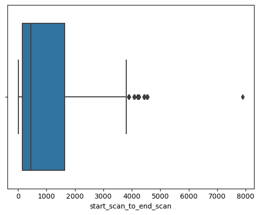

```python
sns.boxplot(x=df["start_scan_to_end_scan"])
```

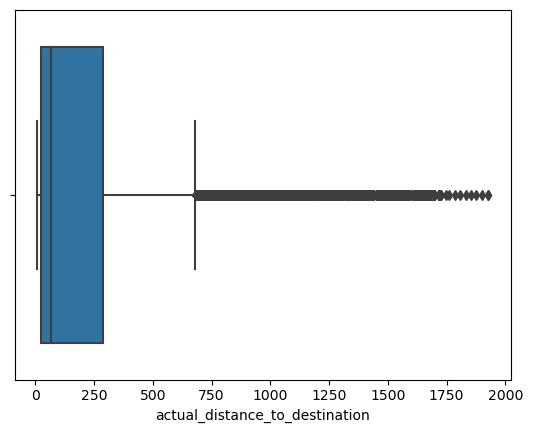

```python
sns.boxplot(x=df["actual_distance_to_destination"])
```

```python
df[df["actual_distance_to_destination"]>750].count()
```

[output not shown]

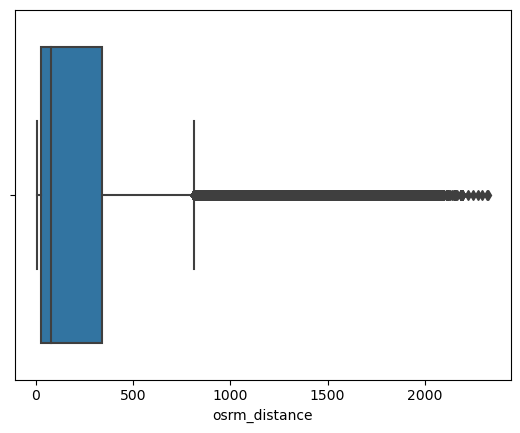

```python
sns.boxplot(x=df["osrm_distance"])
```

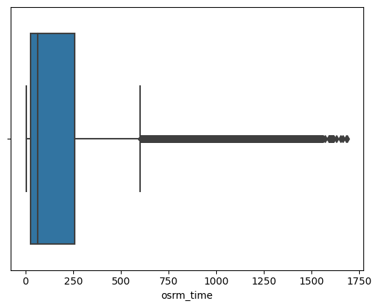

```python
sns.boxplot(x=df["osrm_time"])
```

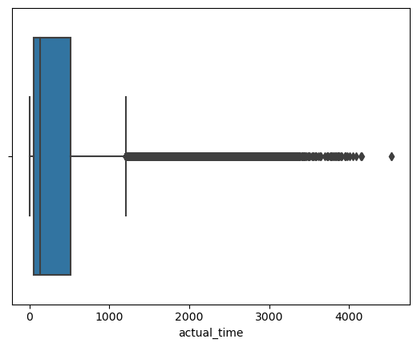

```python
sns.boxplot(x=df["actual_time"])
```

**Insight:** start_scan_to_end_scan seems to be the only one having distinct outlier.

### distribution of the variables and relationship between them (univariate and bivariate plot)

```python
df.describe()
```

|  | start_scan_to_end_scan | cutoff_factor | actual_distance_to_destination | actual_time | osrm_time | osrm_distance | factor | segment_actual_time | segment_osrm_time | segment_osrm_distance | segment_factor |
| --- | --- | --- | --- | --- | --- | --- | --- | --- | --- | --- | --- |
| count | 144867.000000 | 144867.000000 | 144867.000000 | 144867.000000 | 144867.000000 | 144867.000000 | 144867.000000 | 144867.000000 | 144867.000000 | 144867.00000 | 144867.000000 |
| mean | 961.262986 | 232.926567 | 234.073372 | 416.927527 | 213.868272 | 284.771297 | 2.120107 | 36.196111 | 18.507548 | 22.82902 | 2.218368 |
| std | 1037.012769 | 344.755577 | 344.990009 | 598.103621 | 308.011085 | 421.119294 | 1.715421 | 53.571158 | 14.775960 | 17.86066 | 4.847530 |
| min | 20.000000 | 9.000000 | 9.000045 | 9.000000 | 6.000000 | 9.008200 | 0.144000 | -244.000000 | 0.000000 | 0.00000 | -23.444444 |
| 25% | 161.000000 | 22.000000 | 23.355874 | 51.000000 | 27.000000 | 29.914700 | 1.604264 | 20.000000 | 11.000000 | 12.07010 | 1.347826 |
| 50% | 449.000000 | 66.000000 | 66.126571 | 132.000000 | 64.000000 | 78.525800 | 1.857143 | 29.000000 | 17.000000 | 23.51300 | 1.684211 |
| 75% | 1634.000000 | 286.000000 | 286.708875 | 513.000000 | 257.000000 | 343.193250 | 2.213483 | 40.000000 | 22.000000 | 27.81325 | 2.250000 |
| max | 7898.000000 | 1927.000000 | 1927.447705 | 4532.000000 | 1686.000000 | 2326.199100 | 77.387097 | 3051.000000 | 1611.000000 | 2191.40370 | 574.250000 |

```python
df.describe(include=['object'])
```

|  | data | trip_creation_time | route_schedule_uuid | route_type | trip_uuid | source_center | source_name | destination_center | destination_name | od_start_time | od_end_time | cutoff_timestamp |
| --- | --- | --- | --- | --- | --- | --- | --- | --- | --- | --- | --- | --- |
| count | 144867 | 144867 | 144867 | 144867 | 144867 | 144867 | 144574 | 144867 | 144606 | 144867 | 144867 | 144867 |
| unique | 2 | 14817 | 1504 | 2 | 14817 | 1508 | 1498 | 1481 | 1468 | 26369 | 26369 | 93180 |
| top | training | 2018-09-28 05:23:15.359220 | thanos::sroute:4029a8a2-6c74-4b7e-a6d8-f9e069f... | FTL | trip-153811219535896559 | IND000000ACB | Gurgaon_Bilaspur_HB (Haryana) | IND000000ACB | Gurgaon_Bilaspur_HB (Haryana) | 2018-09-21 18:37:09.322207 | 2018-09-24 09:59:15.691618 | 2018-09-24 05:19:20 |
| freq | 104858 | 101 | 1812 | 99660 | 101 | 23347 | 23347 | 15192 | 15192 | 81 | 81 | 40 |

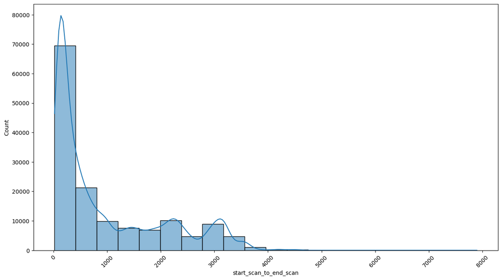

```python
plt.figure(figsize=(15,8))
plt.xticks(rotation=45)
sns.histplot(x="start_scan_to_end_scan", bins=20, data = df, kde=True)
plt.show()
```

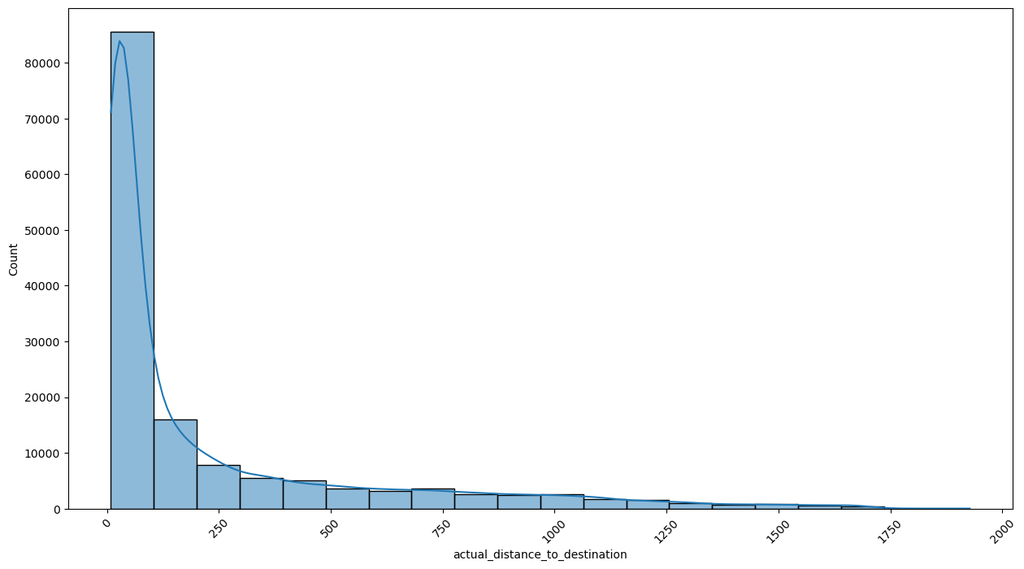

```python
plt.figure(figsize=(15,8))
plt.xticks(rotation=45)
sns.histplot(x="actual_distance_to_destination", bins=20, data = df, kde=True)
plt.show()
```

[figure not shown]

```python
plt.figure(figsize=(15,8))
plt.xticks(rotation=45)
sns.histplot(x="actual_time", bins=25, data = df, kde=True)
plt.show()
```

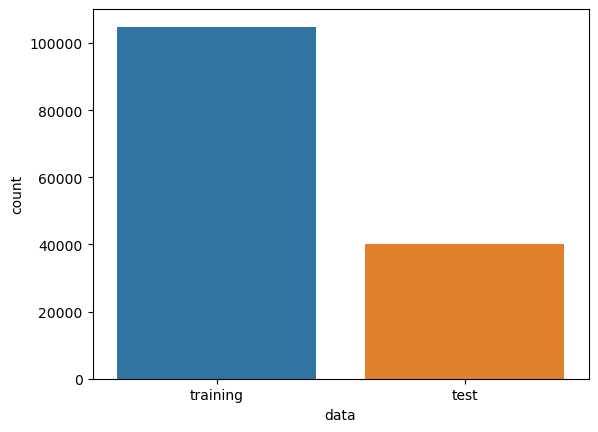

```python
sns.countplot(x ='data', data = df)
plt.show()
```

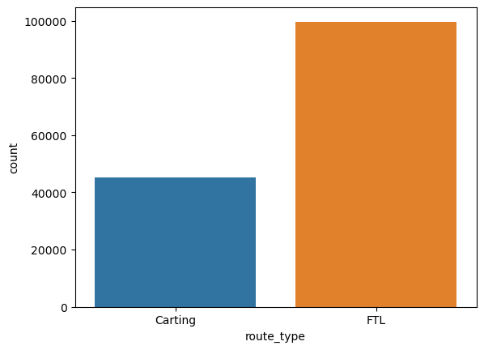

```python
sns.countplot(x ='route_type', data = df)
plt.show()
```

**Insight** : The amount of FTL is almost twice that of carting visualy. Also most of the data in time or distance are not normally distributed.

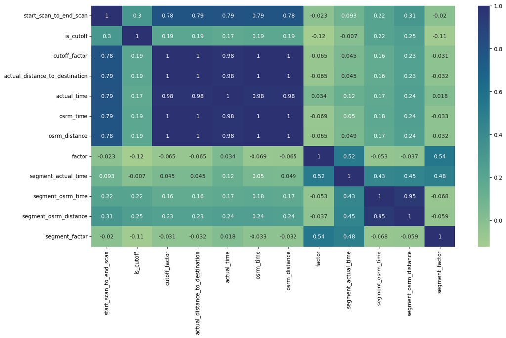

```python
plt.figure(figsize=(15,8))
plt.xticks(rotation=45)
sns.heatmap(df.corr(),annot=True, cmap="crest")
plt.show()
```

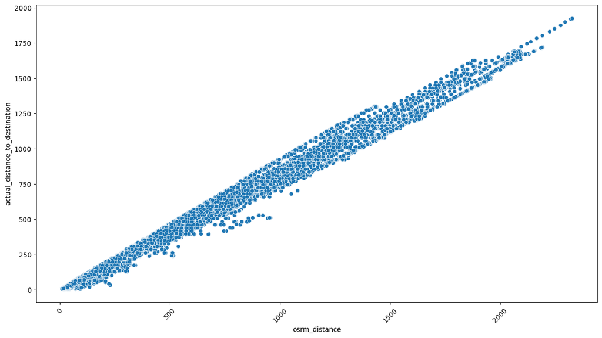

```python
plt.figure(figsize=(15,8))
plt.xticks(rotation=45)
sns.scatterplot(x='osrm_distance',y='actual_distance_to_destination',data=df)
plt.show()
```

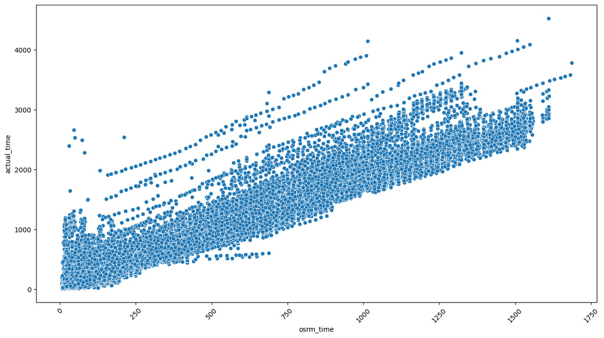

```python
plt.figure(figsize=(15,8))
plt.xticks(rotation=45)
sns.scatterplot(x='osrm_time',y='actual_time',data=df)
plt.show()
```

**Insight:** The accuracy of osrm_distance is higher than osrm time since its closer to a straight line

# Missing values Treatment & Outlier treatment (using the IQR method)

## Handle missing values in the data

```python
df.isna().sum()
```

```
data                                0
trip_creation_time                  0
route_schedule_uuid                 0
route_type                          0
trip_uuid                           0
source_center                       0
source_name                       293
destination_center                  0
destination_name                  261
od_start_time                       0
od_end_time                         0
start_scan_to_end_scan              0
is_cutoff                           0
cutoff_factor                       0
cutoff_timestamp                    0
actual_distance_to_destination      0
actual_time                         0
osrm_time                           0
osrm_distance                       0
factor                              0
segment_actual_time                 0
segment_osrm_time                   0
segment_osrm_distance               0
segment_factor                      0
dtype: int64
```

```python
df[df["source_name"].isna()]["trip_uuid"].unique()
```

```
array(['trip-153786558437756691', 'trip-153842737815495661',
       'trip-153834519721733970', 'trip-153846056503320607',
       'trip-153852612674280168', 'trip-153785822252799564',
       'trip-153835867702133730', 'trip-153843937115921268',
       'trip-153851526862672465', 'trip-153783153973255752',
       'trip-153786712501643905', 'trip-153818244828109704',
       'trip-153777969957700771', 'trip-153802263936969812',
       'trip-153812396555262982', 'trip-153799300352000726',
       'trip-153800882473542201', 'trip-153781894334349262',
       'trip-153833330949418536', 'trip-153836697913613926',
       'trip-153769166516379642', 'trip-153829753238591840',
       'trip-153860002475779846', 'trip-153854526936264994',
       'trip-153824891534925374', 'trip-153785493712368255',
       'trip-153851268207010003', 'trip-153826788460137094',
       'trip-153860203010589724', 'trip-153809438886343536',
       'trip-153790525985329256', 'trip-153792104124206797',
       'trip-153800051661903546', 'trip-153794907452350443',
       'trip-153826587347960527', 'trip-153799759049764136',
       'trip-153791004076950775', 'trip-153739065339036065',
       'trip-153816053387149067', 'trip-153829881746420606',
       'trip-153818227968802218', 'trip-153752033566751074',
       'trip-153811367563100850', 'trip-153760846587062276',
       'trip-153847102374259925', 'trip-153801047876051786',
       'trip-153809656036701745', 'trip-153775037443441088',
       'trip-153842562860298862', 'trip-153779508492576787',
       'trip-153800731291924640', 'trip-153746918356196062',
       'trip-153804224240745898', 'trip-153808726874610853',
       'trip-153795287270071798', 'trip-153776806236494354',
       'trip-153777973100266904', 'trip-153851243698591845',
       'trip-153755911378016076', 'trip-153843109410376388',
       'trip-153794922985641945', 'trip-153821242026370083',
       'trip-153820032399976293', 'trip-153847015570070605',
       'trip-153812758596408063', 'trip-153855756668984584'], dtype=object)
```

```python
len(df["trip_uuid"].unique())
```

```
14817
```

```python
df[df["trip_uuid"]=='trip-153786558437756691']
```

|  | data | trip_creation_time | route_schedule_uuid | route_type | trip_uuid | source_center | source_name | destination_center | destination_name | od_start_time | ... | cutoff_timestamp | actual_distance_to_destination | actual_time | osrm_time | osrm_distance | factor | segment_actual_time | segment_osrm_time | segment_osrm_distance | segment_factor |
| --- | --- | --- | --- | --- | --- | --- | --- | --- | --- | --- | --- | --- | --- | --- | --- | --- | --- | --- | --- | --- | --- |
| 91 | training | 2018-09-25 08:53:04.377810 | thanos::sroute:4460a38d-ab9b-484e-bd4e-f4201d0... | FTL | trip-153786558437756691 | IND302014AAA | Jaipur_Hub (Rajasthan) | IND305001AAC | Ajmer_FoySGRRD_I (Rajasthan) | 2018-09-25 08:53:04.377810 | ... | 2018-09-25 15:33:18 | 22.564533 | 60.0 | 19.0 | 24.1005 | 3.157895 | 60.0 | 19.0 | 24.1005 | 3.157895 |
| 92 | training | 2018-09-25 08:53:04.377810 | thanos::sroute:4460a38d-ab9b-484e-bd4e-f4201d0... | FTL | trip-153786558437756691 | IND302014AAA | Jaipur_Hub (Rajasthan) | IND305001AAC | Ajmer_FoySGRRD_I (Rajasthan) | 2018-09-25 08:53:04.377810 | ... | 2018-09-25 14:35:25 | 45.388095 | 117.0 | 37.0 | 49.1993 | 3.162162 | 57.0 | 17.0 | 25.0988 | 3.352941 |
| 93 | training | 2018-09-25 08:53:04.377810 | thanos::sroute:4460a38d-ab9b-484e-bd4e-f4201d0... | FTL | trip-153786558437756691 | IND302014AAA | Jaipur_Hub (Rajasthan) | IND305001AAC | Ajmer_FoySGRRD_I (Rajasthan) | 2018-09-25 08:53:04.377810 | ... | 2018-09-25 13:53:25 | 78.204766 | 159.0 | 61.0 | 82.8385 | 2.606557 | 42.0 | 23.0 | 33.6391 | 1.826087 |
| 94 | training | 2018-09-25 08:53:04.377810 | thanos::sroute:4460a38d-ab9b-484e-bd4e-f4201d0... | FTL | trip-153786558437756691 | IND302014AAA | Jaipur_Hub (Rajasthan) | IND305001AAC | Ajmer_FoySGRRD_I (Rajasthan) | 2018-09-25 08:53:04.377810 | ... | 2018-09-25 13:41:21 | 88.010616 | 171.0 | 68.0 | 92.6769 | 2.514706 | 12.0 | 6.0 | 9.8384 | 2.000000 |
| 95 | training | 2018-09-25 08:53:04.377810 | thanos::sroute:4460a38d-ab9b-484e-bd4e-f4201d0... | FTL | trip-153786558437756691 | IND302014AAA | Jaipur_Hub (Rajasthan) | IND305001AAC | Ajmer_FoySGRRD_I (Rajasthan) | 2018-09-25 08:53:04.377810 | ... | 2018-09-25 12:50:15 | 115.305349 | 223.0 | 106.0 | 132.1787 | 2.103774 | 51.0 | 37.0 | 39.5019 | 1.378378 |
| 96 | training | 2018-09-25 08:53:04.377810 | thanos::sroute:4460a38d-ab9b-484e-bd4e-f4201d0... | FTL | trip-153786558437756691 | IND302014AAA | Jaipur_Hub (Rajasthan) | IND305001AAC | Ajmer_FoySGRRD_I (Rajasthan) | 2018-09-25 08:53:04.377810 | ... | 2018-09-25 12:05:25 | 125.698345 | 267.0 | 106.0 | 143.0736 | 2.518868 | 44.0 | 19.0 | 16.8866 | 2.315789 |
| 97 | training | 2018-09-25 08:53:04.377810 | thanos::sroute:4460a38d-ab9b-484e-bd4e-f4201d0... | FTL | trip-153786558437756691 | IND305001AAC | Ajmer_FoySGRRD_I (Rajasthan) | IND306401AAB | Pali_Nayagaon_I (Rajasthan) | 2018-09-25 16:37:20.428705 | ... | 2018-09-25 20:47:17 | 25.190138 | 38.0 | 19.0 | 25.4423 | 2.000000 | 38.0 | 19.0 | 25.4423 | 2.000000 |
| 98 | training | 2018-09-25 08:53:04.377810 | thanos::sroute:4460a38d-ab9b-484e-bd4e-f4201d0... | FTL | trip-153786558437756691 | IND305001AAC | Ajmer_FoySGRRD_I (Rajasthan) | IND306401AAB | Pali_Nayagaon_I (Rajasthan) | 2018-09-25 16:37:20.428705 | ... | 2018-09-25 20:19:16 | 45.290594 | 66.0 | 33.0 | 45.7315 | 2.000000 | 28.0 | 14.0 | 20.2893 | 2.000000 |
| 99 | training | 2018-09-25 08:53:04.377810 | thanos::sroute:4460a38d-ab9b-484e-bd4e-f4201d0... | FTL | trip-153786558437756691 | IND305001AAC | Ajmer_FoySGRRD_I (Rajasthan) | IND306401AAB | Pali_Nayagaon_I (Rajasthan) | 2018-09-25 16:37:20.428705 | ... | 2018-09-25 19:35:19 | 68.310679 | 110.0 | 50.0 | 69.2565 | 2.200000 | 43.0 | 16.0 | 23.5250 | 2.687500 |
| 100 | training | 2018-09-25 08:53:04.377810 | thanos::sroute:4460a38d-ab9b-484e-bd4e-f4201d0... | FTL | trip-153786558437756691 | IND305001AAC | Ajmer_FoySGRRD_I (Rajasthan) | IND306401AAB | Pali_Nayagaon_I (Rajasthan) | 2018-09-25 16:37:20.428705 | ... | 2018-09-25 19:05:19 | 88.938831 | 140.0 | 65.0 | 91.2467 | 2.153846 | 30.0 | 15.0 | 21.9902 | 2.000000 |
| 101 | training | 2018-09-25 08:53:04.377810 | thanos::sroute:4460a38d-ab9b-484e-bd4e-f4201d0... | FTL | trip-153786558437756691 | IND305001AAC | Ajmer_FoySGRRD_I (Rajasthan) | IND306401AAB | Pali_Nayagaon_I (Rajasthan) | 2018-09-25 16:37:20.428705 | ... | 2018-09-25 18:27:18 | 111.085466 | 178.0 | 83.0 | 116.6084 | 2.144578 | 38.0 | 17.0 | 25.3616 | 2.235294 |
| 102 | training | 2018-09-25 08:53:04.377810 | thanos::sroute:4460a38d-ab9b-484e-bd4e-f4201d0... | FTL | trip-153786558437756691 | IND305001AAC | Ajmer_FoySGRRD_I (Rajasthan) | IND306401AAB | Pali_Nayagaon_I (Rajasthan) | 2018-09-25 16:37:20.428705 | ... | 2018-09-25 17:59:21 | 132.955382 | 205.0 | 101.0 | 141.0785 | 2.029703 | 27.0 | 17.0 | 24.4701 | 1.588235 |
| 103 | training | 2018-09-25 08:53:04.377810 | thanos::sroute:4460a38d-ab9b-484e-bd4e-f4201d0... | FTL | trip-153786558437756691 | IND305001AAC | Ajmer_FoySGRRD_I (Rajasthan) | IND306401AAB | Pali_Nayagaon_I (Rajasthan) | 2018-09-25 16:37:20.428705 | ... | 2018-09-25 17:23:25 | 147.736748 | 241.0 | 121.0 | 165.0088 | 1.991736 | 35.0 | 20.0 | 23.9303 | 1.750000 |
| 104 | training | 2018-09-25 08:53:04.377810 | thanos::sroute:4460a38d-ab9b-484e-bd4e-f4201d0... | FTL | trip-153786558437756691 | IND306401AAB | Pali_Nayagaon_I (Rajasthan) | IND342005AAD | Jodhpur_Basni_I (Rajasthan) | 2018-09-25 21:31:00.741991 | ... | 2018-09-25 23:23:18 | 23.980240 | 36.0 | 21.0 | 28.2090 | 1.714286 | 36.0 | 21.0 | 28.2090 | 1.714286 |
| 105 | training | 2018-09-25 08:53:04.377810 | thanos::sroute:4460a38d-ab9b-484e-bd4e-f4201d0... | FTL | trip-153786558437756691 | IND306401AAB | Pali_Nayagaon_I (Rajasthan) | IND342005AAD | Jodhpur_Basni_I (Rajasthan) | 2018-09-25 21:31:00.741991 | ... | 2018-09-25 22:51:18 | 44.277515 | 68.0 | 36.0 | 49.6160 | 1.888889 | 32.0 | 15.0 | 21.4070 | 2.133333 |
| 106 | training | 2018-09-25 08:53:04.377810 | thanos::sroute:4460a38d-ab9b-484e-bd4e-f4201d0... | FTL | trip-153786558437756691 | IND306401AAB | Pali_Nayagaon_I (Rajasthan) | IND342005AAD | Jodhpur_Basni_I (Rajasthan) | 2018-09-25 21:31:00.741991 | ... | 2018-09-25 21:31:21.644062 | 61.259881 | 147.0 | 54.0 | 69.9043 | 2.722222 | 79.0 | 18.0 | 20.2883 | 4.388889 |
| 107 | training | 2018-09-25 08:53:04.377810 | thanos::sroute:4460a38d-ab9b-484e-bd4e-f4201d0... | FTL | trip-153786558437756691 | IND342005AAD | Jodhpur_Basni_I (Rajasthan) | IND342601AAA | Piparcity_BsstdDPP_D (Rajasthan) | 2018-09-26 00:21:56.684666 | ... | 2018-09-26 04:05:21 | 22.140261 | 40.0 | 21.0 | 23.7375 | 1.904762 | 40.0 | 21.0 | 23.7375 | 1.904762 |
| 108 | training | 2018-09-25 08:53:04.377810 | thanos::sroute:4460a38d-ab9b-484e-bd4e-f4201d0... | FTL | trip-153786558437756691 | IND342005AAD | Jodhpur_Basni_I (Rajasthan) | IND342601AAA | Piparcity_BsstdDPP_D (Rajasthan) | 2018-09-26 00:21:56.684666 | ... | 2018-09-26 03:29:18 | 45.898786 | 76.0 | 39.0 | 49.0774 | 1.948718 | 36.0 | 18.0 | 25.3399 | 2.000000 |
| 109 | training | 2018-09-25 08:53:04.377810 | thanos::sroute:4460a38d-ab9b-484e-bd4e-f4201d0... | FTL | trip-153786558437756691 | IND342005AAD | Jodhpur_Basni_I (Rajasthan) | IND342601AAA | Piparcity_BsstdDPP_D (Rajasthan) | 2018-09-26 00:21:56.684666 | ... | 2018-09-26 02:19:23 | 56.150112 | 146.0 | 51.0 | 61.5216 | 2.862745 | 69.0 | 11.0 | 12.4441 | 6.272727 |
| 110 | training | 2018-09-25 08:53:04.377810 | thanos::sroute:4460a38d-ab9b-484e-bd4e-f4201d0... | FTL | trip-153786558437756691 | IND342601AAA | Piparcity_BsstdDPP_D (Rajasthan) | IND342902A1B | NaN | 2018-09-26 05:04:49.254901 | ... | 2018-09-26 05:57:25 | 24.538214 | 58.0 | 33.0 | 30.8845 | 1.757576 | 58.0 | 33.0 | 30.8845 | 1.757576 |
| 111 | training | 2018-09-25 08:53:04.377810 | thanos::sroute:4460a38d-ab9b-484e-bd4e-f4201d0... | FTL | trip-153786558437756691 | IND342601AAA | Piparcity_BsstdDPP_D (Rajasthan) | IND342902A1B | NaN | 2018-09-26 05:04:49.254901 | ... | 2018-09-26 05:04:49.254901 | 34.657709 | 110.0 | 43.0 | 41.5361 | 2.558140 | 52.0 | 10.0 | 10.6517 | 5.200000 |
| 112 | training | 2018-09-25 08:53:04.377810 | thanos::sroute:4460a38d-ab9b-484e-bd4e-f4201d0... | FTL | trip-153786558437756691 | IND342902A1B | NaN | IND302014AAA | Jaipur_Hub (Rajasthan) | 2018-09-26 06:58:08.054001 | ... | 2018-09-26 14:09:19 | 22.783440 | 48.0 | 34.0 | 37.7749 | 1.411765 | 48.0 | 34.0 | 37.7749 | 1.411765 |
| 113 | training | 2018-09-25 08:53:04.377810 | thanos::sroute:4460a38d-ab9b-484e-bd4e-f4201d0... | FTL | trip-153786558437756691 | IND342902A1B | NaN | IND302014AAA | Jaipur_Hub (Rajasthan) | 2018-09-26 06:58:08.054001 | ... | 2018-09-26 13:19:23 | 46.071250 | 98.0 | 41.0 | 56.3575 | 2.390244 | 49.0 | 33.0 | 34.1661 | 1.484848 |
| 114 | training | 2018-09-25 08:53:04.377810 | thanos::sroute:4460a38d-ab9b-484e-bd4e-f4201d0... | FTL | trip-153786558437756691 | IND342902A1B | NaN | IND302014AAA | Jaipur_Hub (Rajasthan) | 2018-09-26 06:58:08.054001 | ... | 2018-09-26 12:49:33 | 67.714993 | 127.0 | 58.0 | 80.4811 | 2.189655 | 29.0 | 17.0 | 24.1236 | 1.705882 |
| 115 | training | 2018-09-25 08:53:04.377810 | thanos::sroute:4460a38d-ab9b-484e-bd4e-f4201d0... | FTL | trip-153786558437756691 | IND342902A1B | NaN | IND302014AAA | Jaipur_Hub (Rajasthan) | 2018-09-26 06:58:08.054001 | ... | 2018-09-26 12:21:18 | 88.149642 | 156.0 | 73.0 | 101.2556 | 2.136986 | 28.0 | 14.0 | 20.7746 | 2.000000 |
| 116 | training | 2018-09-25 08:53:04.377810 | thanos::sroute:4460a38d-ab9b-484e-bd4e-f4201d0... | FTL | trip-153786558437756691 | IND342902A1B | NaN | IND302014AAA | Jaipur_Hub (Rajasthan) | 2018-09-26 06:58:08.054001 | ... | 2018-09-26 11:25:24 | 112.691981 | 212.0 | 92.0 | 127.9860 | 2.304348 | 55.0 | 18.0 | 26.7304 | 3.055556 |
| 117 | training | 2018-09-25 08:53:04.377810 | thanos::sroute:4460a38d-ab9b-484e-bd4e-f4201d0... | FTL | trip-153786558437756691 | IND342902A1B | NaN | IND302014AAA | Jaipur_Hub (Rajasthan) | 2018-09-26 06:58:08.054001 | ... | 2018-09-26 10:31:22 | 132.128898 | 266.0 | 117.0 | 156.5566 | 2.273504 | 54.0 | 25.0 | 28.5706 | 2.160000 |
| 118 | training | 2018-09-25 08:53:04.377810 | thanos::sroute:4460a38d-ab9b-484e-bd4e-f4201d0... | FTL | trip-153786558437756691 | IND342902A1B | NaN | IND302014AAA | Jaipur_Hub (Rajasthan) | 2018-09-26 06:58:08.054001 | ... | 2018-09-26 09:43:23 | 154.305625 | 314.0 | 138.0 | 186.5238 | 2.275362 | 47.0 | 21.0 | 29.9673 | 2.238095 |
| 119 | training | 2018-09-25 08:53:04.377810 | thanos::sroute:4460a38d-ab9b-484e-bd4e-f4201d0... | FTL | trip-153786558437756691 | IND342902A1B | NaN | IND302014AAA | Jaipur_Hub (Rajasthan) | 2018-09-26 06:58:08.054001 | ... | 2018-09-26 09:07:27 | 178.611991 | 350.0 | 161.0 | 218.2945 | 2.173913 | 35.0 | 22.0 | 31.7707 | 1.590909 |
| 120 | training | 2018-09-25 08:53:04.377810 | thanos::sroute:4460a38d-ab9b-484e-bd4e-f4201d0... | FTL | trip-153786558437756691 | IND342902A1B | NaN | IND302014AAA | Jaipur_Hub (Rajasthan) | 2018-09-26 06:58:08.054001 | ... | 2018-09-26 08:26:15 | 199.353179 | 391.0 | 176.0 | 234.8976 | 2.221591 | 41.0 | 20.0 | 22.9423 | 2.050000 |
| 121 | training | 2018-09-25 08:53:04.377810 | thanos::sroute:4460a38d-ab9b-484e-bd4e-f4201d0... | FTL | trip-153786558437756691 | IND342902A1B | NaN | IND302014AAA | Jaipur_Hub (Rajasthan) | 2018-09-26 06:58:08.054001 | ... | 2018-09-26 08:05:22 | 208.029246 | 412.0 | 185.0 | 244.0840 | 2.227027 | 20.0 | 8.0 | 9.1864 | 2.500000 |

31 rows × 24 columns

```python
df[(df["source_center"]=="IND342902A1B") | (df["destination_center"]=="IND342902A1B")]
```

|  | data | trip_creation_time | route_schedule_uuid | route_type | trip_uuid | source_center | source_name | destination_center | destination_name | od_start_time | ... | cutoff_timestamp | actual_distance_to_destination | actual_time | osrm_time | osrm_distance | factor | segment_actual_time | segment_osrm_time | segment_osrm_distance | segment_factor |
| --- | --- | --- | --- | --- | --- | --- | --- | --- | --- | --- | --- | --- | --- | --- | --- | --- | --- | --- | --- | --- | --- |
| 110 | training | 2018-09-25 08:53:04.377810 | thanos::sroute:4460a38d-ab9b-484e-bd4e-f4201d0... | FTL | trip-153786558437756691 | IND342601AAA | Piparcity_BsstdDPP_D (Rajasthan) | IND342902A1B | NaN | 2018-09-26 05:04:49.254901 | ... | 2018-09-26 05:57:25 | 24.538214 | 58.0 | 33.0 | 30.8845 | 1.757576 | 58.0 | 33.0 | 30.8845 | 1.757576 |
| 111 | training | 2018-09-25 08:53:04.377810 | thanos::sroute:4460a38d-ab9b-484e-bd4e-f4201d0... | FTL | trip-153786558437756691 | IND342601AAA | Piparcity_BsstdDPP_D (Rajasthan) | IND342902A1B | NaN | 2018-09-26 05:04:49.254901 | ... | 2018-09-26 05:04:49.254901 | 34.657709 | 110.0 | 43.0 | 41.5361 | 2.558140 | 52.0 | 10.0 | 10.6517 | 5.200000 |
| 112 | training | 2018-09-25 08:53:04.377810 | thanos::sroute:4460a38d-ab9b-484e-bd4e-f4201d0... | FTL | trip-153786558437756691 | IND342902A1B | NaN | IND302014AAA | Jaipur_Hub (Rajasthan) | 2018-09-26 06:58:08.054001 | ... | 2018-09-26 14:09:19 | 22.783440 | 48.0 | 34.0 | 37.7749 | 1.411765 | 48.0 | 34.0 | 37.7749 | 1.411765 |
| 113 | training | 2018-09-25 08:53:04.377810 | thanos::sroute:4460a38d-ab9b-484e-bd4e-f4201d0... | FTL | trip-153786558437756691 | IND342902A1B | NaN | IND302014AAA | Jaipur_Hub (Rajasthan) | 2018-09-26 06:58:08.054001 | ... | 2018-09-26 13:19:23 | 46.071250 | 98.0 | 41.0 | 56.3575 | 2.390244 | 49.0 | 33.0 | 34.1661 | 1.484848 |
| 114 | training | 2018-09-25 08:53:04.377810 | thanos::sroute:4460a38d-ab9b-484e-bd4e-f4201d0... | FTL | trip-153786558437756691 | IND342902A1B | NaN | IND302014AAA | Jaipur_Hub (Rajasthan) | 2018-09-26 06:58:08.054001 | ... | 2018-09-26 12:49:33 | 67.714993 | 127.0 | 58.0 | 80.4811 | 2.189655 | 29.0 | 17.0 | 24.1236 | 1.705882 |
| ... | ... | ... | ... | ... | ... | ... | ... | ... | ... | ... | ... | ... | ... | ... | ... | ... | ... | ... | ... | ... | ... |
| 102433 | test | 2018-10-02 09:03:43.743009 | thanos::sroute:88f3c4f2-ba7c-4817-8dff-e181ba3... | FTL | trip-153847102374259925 | IND342902A1B | NaN | IND302014AAA | Jaipur_Hub (Rajasthan) | 2018-10-03 06:26:15.394809 | ... | 2018-10-03 09:23:32 | 132.590047 | 279.0 | 119.0 | 160.7385 | 2.344538 | 60.0 | 29.0 | 34.2473 | 2.068966 |
| 102434 | test | 2018-10-02 09:03:43.743009 | thanos::sroute:88f3c4f2-ba7c-4817-8dff-e181ba3... | FTL | trip-153847102374259925 | IND342902A1B | NaN | IND302014AAA | Jaipur_Hub (Rajasthan) | 2018-10-03 06:26:15.394809 | ... | 2018-10-03 08:50:40 | 155.235386 | 311.0 | 138.0 | 187.3637 | 2.253623 | 32.0 | 18.0 | 26.6252 | 1.777778 |
| 102435 | test | 2018-10-02 09:03:43.743009 | thanos::sroute:88f3c4f2-ba7c-4817-8dff-e181ba3... | FTL | trip-153847102374259925 | IND342902A1B | NaN | IND302014AAA | Jaipur_Hub (Rajasthan) | 2018-10-03 06:26:15.394809 | ... | 2018-10-03 08:20:38 | 176.361211 | 341.0 | 157.0 | 211.0723 | 2.171975 | 30.0 | 19.0 | 23.7085 | 1.578947 |
| 102436 | test | 2018-10-02 09:03:43.743009 | thanos::sroute:88f3c4f2-ba7c-4817-8dff-e181ba3... | FTL | trip-153847102374259925 | IND342902A1B | NaN | IND302014AAA | Jaipur_Hub (Rajasthan) | 2018-10-03 06:26:15.394809 | ... | 2018-10-03 07:44:33 | 199.187091 | 378.0 | 175.0 | 234.5741 | 2.160000 | 36.0 | 26.0 | 26.6927 | 1.384615 |
| 102437 | test | 2018-10-02 09:03:43.743009 | thanos::sroute:88f3c4f2-ba7c-4817-8dff-e181ba3... | FTL | trip-153847102374259925 | IND342902A1B | NaN | IND302014AAA | Jaipur_Hub (Rajasthan) | 2018-10-03 06:26:15.394809 | ... | 2018-10-03 06:59:37 | 207.115282 | 422.0 | 183.0 | 242.8441 | 2.306011 | 44.0 | 7.0 | 8.2700 | 6.285714 |

106 rows × 24 columns

```python
df[df["source_name"].isna()]["source_center"].unique()
```

```
array(['IND342902A1B', 'IND577116AAA', 'IND282002AAD', 'IND465333A1B',
       'IND841301AAC', 'IND509103AAC', 'IND126116AAA', 'IND331022A1B',
       'IND505326AAB', 'IND852118A1B'], dtype=object)
```

```python
df[df["destination_name"].isna()]["destination_center"].unique()
```

```
array(['IND342902A1B', 'IND577116AAA', 'IND282002AAD', 'IND465333A1B',
       'IND841301AAC', 'IND505326AAB', 'IND852118A1B', 'IND126116AAA',
       'IND509103AAC', 'IND221005A1A', 'IND250002AAC', 'IND331001A1C',
       'IND122015AAC'], dtype=object)
```

Seems like "IND342902A1B" and some other source and destination center are ones whose names are missing

**So instead of dropping missing values we can replace the missing names with the corresponding centre code**

```python
df.groupby(["source_center","source_name"])
```

```
<pandas.core.groupby.generic.DataFrameGroupBy object at 0x00000277E81B9D00>
```

```python
df.loc[df['source_name'].isna(), 'source_name'] = df["source_center"]
```

```python
df.loc[df['destination_name'].isna(), 'destination_name'] = df["destination_center"]
```

```python
df.head()
```

|  | data | trip_creation_time | route_schedule_uuid | route_type | trip_uuid | source_center | source_name | destination_center | destination_name | od_start_time | ... | cutoff_timestamp | actual_distance_to_destination | actual_time | osrm_time | osrm_distance | factor | segment_actual_time | segment_osrm_time | segment_osrm_distance | segment_factor |
| --- | --- | --- | --- | --- | --- | --- | --- | --- | --- | --- | --- | --- | --- | --- | --- | --- | --- | --- | --- | --- | --- |
| 0 | training | 2018-09-20 02:35:36.476840 | thanos::sroute:eb7bfc78-b351-4c0e-a951-fa3d5c3... | Carting | trip-153741093647649320 | IND388121AAA | Anand_VUNagar_DC (Gujarat) | IND388620AAB | Khambhat_MotvdDPP_D (Gujarat) | 2018-09-20 03:21:32.418600 | ... | 2018-09-20 04:27:55 | 10.435660 | 14.0 | 11.0 | 11.9653 | 1.272727 | 14.0 | 11.0 | 11.9653 | 1.272727 |
| 1 | training | 2018-09-20 02:35:36.476840 | thanos::sroute:eb7bfc78-b351-4c0e-a951-fa3d5c3... | Carting | trip-153741093647649320 | IND388121AAA | Anand_VUNagar_DC (Gujarat) | IND388620AAB | Khambhat_MotvdDPP_D (Gujarat) | 2018-09-20 03:21:32.418600 | ... | 2018-09-20 04:17:55 | 18.936842 | 24.0 | 20.0 | 21.7243 | 1.200000 | 10.0 | 9.0 | 9.7590 | 1.111111 |
| 2 | training | 2018-09-20 02:35:36.476840 | thanos::sroute:eb7bfc78-b351-4c0e-a951-fa3d5c3... | Carting | trip-153741093647649320 | IND388121AAA | Anand_VUNagar_DC (Gujarat) | IND388620AAB | Khambhat_MotvdDPP_D (Gujarat) | 2018-09-20 03:21:32.418600 | ... | 2018-09-20 04:01:19.505586 | 27.637279 | 40.0 | 28.0 | 32.5395 | 1.428571 | 16.0 | 7.0 | 10.8152 | 2.285714 |
| 3 | training | 2018-09-20 02:35:36.476840 | thanos::sroute:eb7bfc78-b351-4c0e-a951-fa3d5c3... | Carting | trip-153741093647649320 | IND388121AAA | Anand_VUNagar_DC (Gujarat) | IND388620AAB | Khambhat_MotvdDPP_D (Gujarat) | 2018-09-20 03:21:32.418600 | ... | 2018-09-20 03:39:57 | 36.118028 | 62.0 | 40.0 | 45.5620 | 1.550000 | 21.0 | 12.0 | 13.0224 | 1.750000 |
| 4 | training | 2018-09-20 02:35:36.476840 | thanos::sroute:eb7bfc78-b351-4c0e-a951-fa3d5c3... | Carting | trip-153741093647649320 | IND388121AAA | Anand_VUNagar_DC (Gujarat) | IND388620AAB | Khambhat_MotvdDPP_D (Gujarat) | 2018-09-20 03:21:32.418600 | ... | 2018-09-20 03:33:55 | 39.386040 | 68.0 | 44.0 | 54.2181 | 1.545455 | 6.0 | 5.0 | 3.9153 | 1.200000 |

5 rows × 24 columns

```python
df.isna().sum()
```

```
data                              0
trip_creation_time                0
route_schedule_uuid               0
route_type                        0
trip_uuid                         0
source_center                     0
source_name                       0
destination_center                0
destination_name                  0
od_start_time                     0
od_end_time                       0
start_scan_to_end_scan            0
is_cutoff                         0
cutoff_factor                     0
cutoff_timestamp                  0
actual_distance_to_destination    0
actual_time                       0
osrm_time                         0
osrm_distance                     0
factor                            0
segment_actual_time               0
segment_osrm_time                 0
segment_osrm_distance             0
segment_factor                    0
dtype: int64
```

**Insight:** All missing values has been removed successfully

## Outlier detection

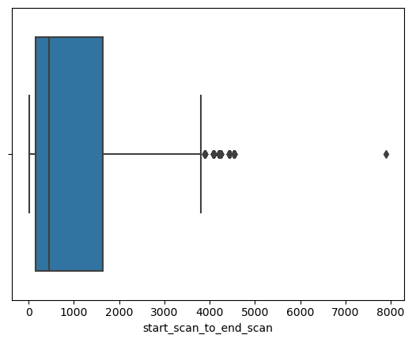

```python
sns.boxplot(x=df["start_scan_to_end_scan"])
```

```python
Q1 = np.percentile(df["start_scan_to_end_scan"], 25, interpolation = 'midpoint')
Q2 = np.percentile(df["start_scan_to_end_scan"], 50, interpolation = 'midpoint')
Q3 = np.percentile(df["start_scan_to_end_scan"], 75, interpolation = 'midpoint')

print('Q1 25 percentile of the given data is, ', Q1)
print('Q1 50 percentile of the given data is, ', Q2)
print('Q1 75 percentile of the given data is, ', Q3)

IQR = Q3 - Q1
print('Interquartile range is', IQR)
upperWhisker = Q3 + 1.5*IQR
print('upper limit',upperWhisker)
```

```
Q1 25 percentile of the given data is,  161.0
Q1 50 percentile of the given data is,  449.0
Q1 75 percentile of the given data is,  1634.0
Interquartile range is 1473.0
upper limit 3843.5
```

```python
df[df["start_scan_to_end_scan"]>upperWhisker]
```

|  | data | trip_creation_time | route_schedule_uuid | route_type | trip_uuid | source_center | source_name | destination_center | destination_name | od_start_time | ... | cutoff_timestamp | actual_distance_to_destination | actual_time | osrm_time | osrm_distance | factor | segment_actual_time | segment_osrm_time | segment_osrm_distance | segment_factor |
| --- | --- | --- | --- | --- | --- | --- | --- | --- | --- | --- | --- | --- | --- | --- | --- | --- | --- | --- | --- | --- | --- |
| 32950 | training | 2018-09-13 01:28:45.326644 | thanos::sroute:6b87651c-fdf4-432f-bf80-0e394f3... | FTL | trip-153680212532637033 | IND712311AAA | Kolkata_Dankuni_HB (West Bengal) | IND781018AAB | Guwahati_Hub (Assam) | 2018-09-13 01:28:45.326644 | ... | 2018-09-15 09:59:21 | 22.370663 | 57.0 | 36.0 | 39.3493 | 1.583333 | 57.0 | 36.0 | 39.3493 | 1.583333 |
| 32951 | training | 2018-09-13 01:28:45.326644 | thanos::sroute:6b87651c-fdf4-432f-bf80-0e394f3... | FTL | trip-153680212532637033 | IND712311AAA | Kolkata_Dankuni_HB (West Bengal) | IND781018AAB | Guwahati_Hub (Assam) | 2018-09-13 01:28:45.326644 | ... | 2018-09-15 09:11:23 | 44.402060 | 105.0 | 64.0 | 78.6763 | 1.640625 | 47.0 | 27.0 | 39.3270 | 1.740741 |
| 32952 | training | 2018-09-13 01:28:45.326644 | thanos::sroute:6b87651c-fdf4-432f-bf80-0e394f3... | FTL | trip-153680212532637033 | IND712311AAA | Kolkata_Dankuni_HB (West Bengal) | IND781018AAB | Guwahati_Hub (Assam) | 2018-09-13 01:28:45.326644 | ... | 2018-09-15 08:11:31 | 68.958075 | 165.0 | 92.0 | 118.7763 | 1.793478 | 59.0 | 28.0 | 40.1000 | 2.107143 |
| 32953 | training | 2018-09-13 01:28:45.326644 | thanos::sroute:6b87651c-fdf4-432f-bf80-0e394f3... | FTL | trip-153680212532637033 | IND712311AAA | Kolkata_Dankuni_HB (West Bengal) | IND781018AAB | Guwahati_Hub (Assam) | 2018-09-13 01:28:45.326644 | ... | 2018-09-15 07:27:32 | 89.822481 | 209.0 | 102.0 | 133.1381 | 2.049020 | 43.0 | 25.0 | 35.8611 | 1.720000 |
| 32954 | training | 2018-09-13 01:28:45.326644 | thanos::sroute:6b87651c-fdf4-432f-bf80-0e394f3... | FTL | trip-153680212532637033 | IND712311AAA | Kolkata_Dankuni_HB (West Bengal) | IND781018AAB | Guwahati_Hub (Assam) | 2018-09-13 01:28:45.326644 | ... | 2018-09-15 05:47:23 | 110.360839 | 309.0 | 121.0 | 159.9273 | 2.553719 | 100.0 | 18.0 | 26.7892 | 5.555556 |
| ... | ... | ... | ... | ... | ... | ... | ... | ... | ... | ... | ... | ... | ... | ... | ... | ... | ... | ... | ... | ... | ... |
| 79524 | training | 2018-09-19 13:44:58.665210 | thanos::sroute:bc7dbb1d-9379-4674-b8d3-f9c3b96... | FTL | trip-153736469866480991 | IND000000ACB | Gurgaon_Bilaspur_HB (Haryana) | IND712311AAA | Kolkata_Dankuni_HB (West Bengal) | 2018-09-19 13:44:58.665210 | ... | 2018-09-19 18:47:20 | 1254.334355 | 3854.0 | 973.0 | 1377.4674 | 3.960946 | 52.0 | 24.0 | 33.8311 | 2.166667 |
| 79525 | training | 2018-09-19 13:44:58.665210 | thanos::sroute:bc7dbb1d-9379-4674-b8d3-f9c3b96... | FTL | trip-153736469866480991 | IND000000ACB | Gurgaon_Bilaspur_HB (Haryana) | IND712311AAA | Kolkata_Dankuni_HB (West Bengal) | 2018-09-19 13:44:58.665210 | ... | 2018-09-19 18:21:19 | 1276.644697 | 3880.0 | 990.0 | 1400.5472 | 3.919192 | 26.0 | 17.0 | 23.0798 | 1.529412 |
| 79526 | training | 2018-09-19 13:44:58.665210 | thanos::sroute:bc7dbb1d-9379-4674-b8d3-f9c3b96... | FTL | trip-153736469866480991 | IND000000ACB | Gurgaon_Bilaspur_HB (Haryana) | IND712311AAA | Kolkata_Dankuni_HB (West Bengal) | 2018-09-19 13:44:58.665210 | ... | 2018-09-19 17:53:20 | 1300.489196 | 3908.0 | 1010.0 | 1426.5927 | 3.869307 | 27.0 | 19.0 | 26.0456 | 1.421053 |
| 79527 | training | 2018-09-19 13:44:58.665210 | thanos::sroute:bc7dbb1d-9379-4674-b8d3-f9c3b96... | FTL | trip-153736469866480991 | IND000000ACB | Gurgaon_Bilaspur_HB (Haryana) | IND712311AAA | Kolkata_Dankuni_HB (West Bengal) | 2018-09-19 13:44:58.665210 | ... | 2018-09-19 13:49:19 | 1300.480089 | 4152.0 | 1015.0 | 1427.0313 | 4.090640 | 244.0 | 15.0 | 15.5571 | 16.266667 |
| 123196 | test | 2018-10-01 23:35:54.432745 | thanos::sroute:4316e05f-b4cc-4ea7-b801-62a93ae... | Carting | trip-153843695443252828 | IND764071AAB | Pappadahandi_Central_DPP_2 (Orissa) | IND530012AAA | Visakhapatnam_Gajuwaka_IP (Andhra Pradesh) | 2018-10-02 15:21:51.236205 | ... | 2018-10-02 15:32:30 | 196.451691 | 2541.0 | 211.0 | 293.3271 | 12.042654 | 2541.0 | 211.0 | 293.3271 | 12.042654 |

373 rows × 24 columns

```python
df.drop(df[df["start_scan_to_end_scan"]>upperWhisker].index , inplace=True)
```

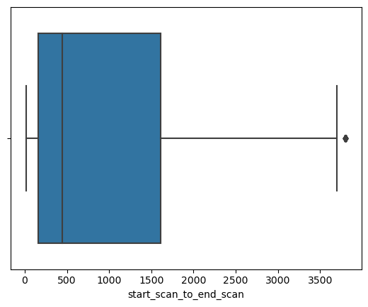

```python
sns.boxplot(x=df["start_scan_to_end_scan"])
```

# Feature Creation

## Destination Name: Split and extract features out of destination. City-place-code (State)

```python
temp=df["destination_name"].str.split("_",  expand = True)
temp
```

|  | 0 | 1 | 2 | 3 |
| --- | --- | --- | --- | --- |
| 0 | Khambhat | MotvdDPP | D (Gujarat) | None |
| 1 | Khambhat | MotvdDPP | D (Gujarat) | None |
| 2 | Khambhat | MotvdDPP | D (Gujarat) | None |
| 3 | Khambhat | MotvdDPP | D (Gujarat) | None |
| 4 | Khambhat | MotvdDPP | D (Gujarat) | None |
| ... | ... | ... | ... | ... |
| 144862 | Gurgaon | Bilaspur | HB (Haryana) | None |
| 144863 | Gurgaon | Bilaspur | HB (Haryana) | None |
| 144864 | Gurgaon | Bilaspur | HB (Haryana) | None |
| 144865 | Gurgaon | Bilaspur | HB (Haryana) | None |
| 144866 | Gurgaon | Bilaspur | HB (Haryana) | None |

144494 rows × 4 columns

```python
df['destination_city']=temp[0]
```

```python
df['destination_place']=temp[1]
```

```python
df['destination_code_state']=temp[2]
```

```python
df.head()
```

|  | data | trip_creation_time | route_schedule_uuid | route_type | trip_uuid | source_center | source_name | destination_center | destination_name | od_start_time | ... | osrm_time | osrm_distance | factor | segment_actual_time | segment_osrm_time | segment_osrm_distance | segment_factor | destination_city | destination_place | destination_code_state |
| --- | --- | --- | --- | --- | --- | --- | --- | --- | --- | --- | --- | --- | --- | --- | --- | --- | --- | --- | --- | --- | --- |
| 0 | training | 2018-09-20 02:35:36.476840 | thanos::sroute:eb7bfc78-b351-4c0e-a951-fa3d5c3... | Carting | trip-153741093647649320 | IND388121AAA | Anand_VUNagar_DC (Gujarat) | IND388620AAB | Khambhat_MotvdDPP_D (Gujarat) | 2018-09-20 03:21:32.418600 | ... | 11.0 | 11.9653 | 1.272727 | 14.0 | 11.0 | 11.9653 | 1.272727 | Khambhat | MotvdDPP | D (Gujarat) |
| 1 | training | 2018-09-20 02:35:36.476840 | thanos::sroute:eb7bfc78-b351-4c0e-a951-fa3d5c3... | Carting | trip-153741093647649320 | IND388121AAA | Anand_VUNagar_DC (Gujarat) | IND388620AAB | Khambhat_MotvdDPP_D (Gujarat) | 2018-09-20 03:21:32.418600 | ... | 20.0 | 21.7243 | 1.200000 | 10.0 | 9.0 | 9.7590 | 1.111111 | Khambhat | MotvdDPP | D (Gujarat) |
| 2 | training | 2018-09-20 02:35:36.476840 | thanos::sroute:eb7bfc78-b351-4c0e-a951-fa3d5c3... | Carting | trip-153741093647649320 | IND388121AAA | Anand_VUNagar_DC (Gujarat) | IND388620AAB | Khambhat_MotvdDPP_D (Gujarat) | 2018-09-20 03:21:32.418600 | ... | 28.0 | 32.5395 | 1.428571 | 16.0 | 7.0 | 10.8152 | 2.285714 | Khambhat | MotvdDPP | D (Gujarat) |
| 3 | training | 2018-09-20 02:35:36.476840 | thanos::sroute:eb7bfc78-b351-4c0e-a951-fa3d5c3... | Carting | trip-153741093647649320 | IND388121AAA | Anand_VUNagar_DC (Gujarat) | IND388620AAB | Khambhat_MotvdDPP_D (Gujarat) | 2018-09-20 03:21:32.418600 | ... | 40.0 | 45.5620 | 1.550000 | 21.0 | 12.0 | 13.0224 | 1.750000 | Khambhat | MotvdDPP | D (Gujarat) |
| 4 | training | 2018-09-20 02:35:36.476840 | thanos::sroute:eb7bfc78-b351-4c0e-a951-fa3d5c3... | Carting | trip-153741093647649320 | IND388121AAA | Anand_VUNagar_DC (Gujarat) | IND388620AAB | Khambhat_MotvdDPP_D (Gujarat) | 2018-09-20 03:21:32.418600 | ... | 44.0 | 54.2181 | 1.545455 | 6.0 | 5.0 | 3.9153 | 1.200000 | Khambhat | MotvdDPP | D (Gujarat) |

5 rows × 27 columns

**Insight:** Destination city , place and state are separated in to separate columns

## Source Name: Split and extract features out of destination. City-place-code (State)

```python
temp=df["source_name"].str.split("_",  expand = True)
temp
```

|  | 0 | 1 | 2 | 3 |
| --- | --- | --- | --- | --- |
| 0 | Anand | VUNagar | DC (Gujarat) | None |
| 1 | Anand | VUNagar | DC (Gujarat) | None |
| 2 | Anand | VUNagar | DC (Gujarat) | None |
| 3 | Anand | VUNagar | DC (Gujarat) | None |
| 4 | Anand | VUNagar | DC (Gujarat) | None |
| ... | ... | ... | ... | ... |
| 144862 | Sonipat | Kundli | H (Haryana) | None |
| 144863 | Sonipat | Kundli | H (Haryana) | None |
| 144864 | Sonipat | Kundli | H (Haryana) | None |
| 144865 | Sonipat | Kundli | H (Haryana) | None |
| 144866 | Sonipat | Kundli | H (Haryana) | None |

144494 rows × 4 columns

```python
df['source_city']=temp[0]
df['source_place']=temp[1]
df['source_code_state']=temp[2]
```

```python
df.head()
```

|  | data | trip_creation_time | route_schedule_uuid | route_type | trip_uuid | source_center | source_name | destination_center | destination_name | od_start_time | ... | segment_actual_time | segment_osrm_time | segment_osrm_distance | segment_factor | destination_city | destination_place | destination_code_state | source_city | source_place | source_code_state |
| --- | --- | --- | --- | --- | --- | --- | --- | --- | --- | --- | --- | --- | --- | --- | --- | --- | --- | --- | --- | --- | --- |
| 0 | training | 2018-09-20 02:35:36.476840 | thanos::sroute:eb7bfc78-b351-4c0e-a951-fa3d5c3... | Carting | trip-153741093647649320 | IND388121AAA | Anand_VUNagar_DC (Gujarat) | IND388620AAB | Khambhat_MotvdDPP_D (Gujarat) | 2018-09-20 03:21:32.418600 | ... | 14.0 | 11.0 | 11.9653 | 1.272727 | Khambhat | MotvdDPP | D (Gujarat) | Anand | VUNagar | DC (Gujarat) |
| 1 | training | 2018-09-20 02:35:36.476840 | thanos::sroute:eb7bfc78-b351-4c0e-a951-fa3d5c3... | Carting | trip-153741093647649320 | IND388121AAA | Anand_VUNagar_DC (Gujarat) | IND388620AAB | Khambhat_MotvdDPP_D (Gujarat) | 2018-09-20 03:21:32.418600 | ... | 10.0 | 9.0 | 9.7590 | 1.111111 | Khambhat | MotvdDPP | D (Gujarat) | Anand | VUNagar | DC (Gujarat) |
| 2 | training | 2018-09-20 02:35:36.476840 | thanos::sroute:eb7bfc78-b351-4c0e-a951-fa3d5c3... | Carting | trip-153741093647649320 | IND388121AAA | Anand_VUNagar_DC (Gujarat) | IND388620AAB | Khambhat_MotvdDPP_D (Gujarat) | 2018-09-20 03:21:32.418600 | ... | 16.0 | 7.0 | 10.8152 | 2.285714 | Khambhat | MotvdDPP | D (Gujarat) | Anand | VUNagar | DC (Gujarat) |
| 3 | training | 2018-09-20 02:35:36.476840 | thanos::sroute:eb7bfc78-b351-4c0e-a951-fa3d5c3... | Carting | trip-153741093647649320 | IND388121AAA | Anand_VUNagar_DC (Gujarat) | IND388620AAB | Khambhat_MotvdDPP_D (Gujarat) | 2018-09-20 03:21:32.418600 | ... | 21.0 | 12.0 | 13.0224 | 1.750000 | Khambhat | MotvdDPP | D (Gujarat) | Anand | VUNagar | DC (Gujarat) |
| 4 | training | 2018-09-20 02:35:36.476840 | thanos::sroute:eb7bfc78-b351-4c0e-a951-fa3d5c3... | Carting | trip-153741093647649320 | IND388121AAA | Anand_VUNagar_DC (Gujarat) | IND388620AAB | Khambhat_MotvdDPP_D (Gujarat) | 2018-09-20 03:21:32.418600 | ... | 6.0 | 5.0 | 3.9153 | 1.200000 | Khambhat | MotvdDPP | D (Gujarat) | Anand | VUNagar | DC (Gujarat) |

5 rows × 30 columns

**Insight:** Source city , place and state are separated in to separate columns

## Trip_creation_time: Extract features like month, year and day etc

```python
df.info()
```

```
<class 'pandas.core.frame.DataFrame'>
Int64Index: 144494 entries, 0 to 144866
Data columns (total 30 columns):
 #   Column                          Non-Null Count   Dtype
---  ------                          --------------   -----
 0   data                            144494 non-null  object
 1   trip_creation_time              144494 non-null  object
 2   route_schedule_uuid             144494 non-null  object
 3   route_type                      144494 non-null  object
 4   trip_uuid                       144494 non-null  object
 5   source_center                   144494 non-null  object
 6   source_name                     144494 non-null  object
 7   destination_center              144494 non-null  object
 8   destination_name                144494 non-null  object
 9   od_start_time                   144494 non-null  object
```

[output cut: 22 more lines]

```python
df['trip_creation_time'] = pd.to_datetime(df['trip_creation_time'])
```

```python
df.info()
```

```
<class 'pandas.core.frame.DataFrame'>
Int64Index: 144494 entries, 0 to 144866
Data columns (total 30 columns):
 #   Column                          Non-Null Count   Dtype
---  ------                          --------------   -----
 0   data                            144494 non-null  object
 1   trip_creation_time              144494 non-null  datetime64[ns]
 2   route_schedule_uuid             144494 non-null  object
 3   route_type                      144494 non-null  object
 4   trip_uuid                       144494 non-null  object
 5   source_center                   144494 non-null  object
 6   source_name                     144494 non-null  object
 7   destination_center              144494 non-null  object
 8   destination_name                144494 non-null  object
 9   od_start_time                   144494 non-null  object
```

[output cut: 22 more lines]

```python
df['trip_month'] = df['trip_creation_time'].dt.month
df['trip_year']= df['trip_creation_time'].dt.year
```

```python
df['trip_day']=df['trip_creation_time'].dt.day
```

```python
df.head()
```

|  | data | trip_creation_time | route_schedule_uuid | route_type | trip_uuid | source_center | source_name | destination_center | destination_name | od_start_time | ... | segment_factor | destination_city | destination_place | destination_code_state | source_city | source_place | source_code_state | trip_month | trip_year | trip_day |
| --- | --- | --- | --- | --- | --- | --- | --- | --- | --- | --- | --- | --- | --- | --- | --- | --- | --- | --- | --- | --- | --- |
| 0 | training | 2018-09-20 02:35:36.476840 | thanos::sroute:eb7bfc78-b351-4c0e-a951-fa3d5c3... | Carting | trip-153741093647649320 | IND388121AAA | Anand_VUNagar_DC (Gujarat) | IND388620AAB | Khambhat_MotvdDPP_D (Gujarat) | 2018-09-20 03:21:32.418600 | ... | 1.272727 | Khambhat | MotvdDPP | D (Gujarat) | Anand | VUNagar | DC (Gujarat) | 9 | 2018 | 20 |
| 1 | training | 2018-09-20 02:35:36.476840 | thanos::sroute:eb7bfc78-b351-4c0e-a951-fa3d5c3... | Carting | trip-153741093647649320 | IND388121AAA | Anand_VUNagar_DC (Gujarat) | IND388620AAB | Khambhat_MotvdDPP_D (Gujarat) | 2018-09-20 03:21:32.418600 | ... | 1.111111 | Khambhat | MotvdDPP | D (Gujarat) | Anand | VUNagar | DC (Gujarat) | 9 | 2018 | 20 |
| 2 | training | 2018-09-20 02:35:36.476840 | thanos::sroute:eb7bfc78-b351-4c0e-a951-fa3d5c3... | Carting | trip-153741093647649320 | IND388121AAA | Anand_VUNagar_DC (Gujarat) | IND388620AAB | Khambhat_MotvdDPP_D (Gujarat) | 2018-09-20 03:21:32.418600 | ... | 2.285714 | Khambhat | MotvdDPP | D (Gujarat) | Anand | VUNagar | DC (Gujarat) | 9 | 2018 | 20 |
| 3 | training | 2018-09-20 02:35:36.476840 | thanos::sroute:eb7bfc78-b351-4c0e-a951-fa3d5c3... | Carting | trip-153741093647649320 | IND388121AAA | Anand_VUNagar_DC (Gujarat) | IND388620AAB | Khambhat_MotvdDPP_D (Gujarat) | 2018-09-20 03:21:32.418600 | ... | 1.750000 | Khambhat | MotvdDPP | D (Gujarat) | Anand | VUNagar | DC (Gujarat) | 9 | 2018 | 20 |
| 4 | training | 2018-09-20 02:35:36.476840 | thanos::sroute:eb7bfc78-b351-4c0e-a951-fa3d5c3... | Carting | trip-153741093647649320 | IND388121AAA | Anand_VUNagar_DC (Gujarat) | IND388620AAB | Khambhat_MotvdDPP_D (Gujarat) | 2018-09-20 03:21:32.418600 | ... | 1.200000 | Khambhat | MotvdDPP | D (Gujarat) | Anand | VUNagar | DC (Gujarat) | 9 | 2018 | 20 |

5 rows × 33 columns

**Insight:** extracted month, year and day separately from trip creation time

## Calculate the time taken between od_start_time and od_end_time and keep it as a feature. Drop the original columns, if required

```python
df['od_start_time'] = pd.to_datetime(df['od_start_time'])
df['od_end_time'] = pd.to_datetime(df['od_end_time'])
```

```python
df.info()
```

```
<class 'pandas.core.frame.DataFrame'>
Int64Index: 144494 entries, 0 to 144866
Data columns (total 33 columns):
 #   Column                          Non-Null Count   Dtype
---  ------                          --------------   -----
 0   data                            144494 non-null  object
 1   trip_creation_time              144494 non-null  datetime64[ns]
 2   route_schedule_uuid             144494 non-null  object
 3   route_type                      144494 non-null  object
 4   trip_uuid                       144494 non-null  object
 5   source_center                   144494 non-null  object
 6   source_name                     144494 non-null  object
 7   destination_center              144494 non-null  object
 8   destination_name                144494 non-null  object
 9   od_start_time                   144494 non-null  datetime64[ns]
```

[output cut: 25 more lines]

```python
df['total_time'] = (df['od_end_time']-df['od_start_time'])
```

```python
df['total_time'] = np.round(df['total_time'].dt.seconds / 60 , 2)
```

```python
df.head()
```

|  | data | trip_creation_time | route_schedule_uuid | route_type | trip_uuid | source_center | source_name | destination_center | destination_name | od_start_time | ... | destination_city | destination_place | destination_code_state | source_city | source_place | source_code_state | trip_month | trip_year | trip_day | total_time |
| --- | --- | --- | --- | --- | --- | --- | --- | --- | --- | --- | --- | --- | --- | --- | --- | --- | --- | --- | --- | --- | --- |
| 0 | training | 2018-09-20 02:35:36.476840 | thanos::sroute:eb7bfc78-b351-4c0e-a951-fa3d5c3... | Carting | trip-153741093647649320 | IND388121AAA | Anand_VUNagar_DC (Gujarat) | IND388620AAB | Khambhat_MotvdDPP_D (Gujarat) | 2018-09-20 03:21:32.418600 | ... | Khambhat | MotvdDPP | D (Gujarat) | Anand | VUNagar | DC (Gujarat) | 9 | 2018 | 20 | 86.2 |
| 1 | training | 2018-09-20 02:35:36.476840 | thanos::sroute:eb7bfc78-b351-4c0e-a951-fa3d5c3... | Carting | trip-153741093647649320 | IND388121AAA | Anand_VUNagar_DC (Gujarat) | IND388620AAB | Khambhat_MotvdDPP_D (Gujarat) | 2018-09-20 03:21:32.418600 | ... | Khambhat | MotvdDPP | D (Gujarat) | Anand | VUNagar | DC (Gujarat) | 9 | 2018 | 20 | 86.2 |
| 2 | training | 2018-09-20 02:35:36.476840 | thanos::sroute:eb7bfc78-b351-4c0e-a951-fa3d5c3... | Carting | trip-153741093647649320 | IND388121AAA | Anand_VUNagar_DC (Gujarat) | IND388620AAB | Khambhat_MotvdDPP_D (Gujarat) | 2018-09-20 03:21:32.418600 | ... | Khambhat | MotvdDPP | D (Gujarat) | Anand | VUNagar | DC (Gujarat) | 9 | 2018 | 20 | 86.2 |
| 3 | training | 2018-09-20 02:35:36.476840 | thanos::sroute:eb7bfc78-b351-4c0e-a951-fa3d5c3... | Carting | trip-153741093647649320 | IND388121AAA | Anand_VUNagar_DC (Gujarat) | IND388620AAB | Khambhat_MotvdDPP_D (Gujarat) | 2018-09-20 03:21:32.418600 | ... | Khambhat | MotvdDPP | D (Gujarat) | Anand | VUNagar | DC (Gujarat) | 9 | 2018 | 20 | 86.2 |
| 4 | training | 2018-09-20 02:35:36.476840 | thanos::sroute:eb7bfc78-b351-4c0e-a951-fa3d5c3... | Carting | trip-153741093647649320 | IND388121AAA | Anand_VUNagar_DC (Gujarat) | IND388620AAB | Khambhat_MotvdDPP_D (Gujarat) | 2018-09-20 03:21:32.418600 | ... | Khambhat | MotvdDPP | D (Gujarat) | Anand | VUNagar | DC (Gujarat) | 9 | 2018 | 20 | 86.2 |

5 rows × 34 columns

```python
df.info()
```

```
<class 'pandas.core.frame.DataFrame'>
Int64Index: 144494 entries, 0 to 144866
Data columns (total 34 columns):
 #   Column                          Non-Null Count   Dtype
---  ------                          --------------   -----
 0   data                            144494 non-null  object
 1   trip_creation_time              144494 non-null  datetime64[ns]
 2   route_schedule_uuid             144494 non-null  object
 3   route_type                      144494 non-null  object
 4   trip_uuid                       144494 non-null  object
 5   source_center                   144494 non-null  object
 6   source_name                     144494 non-null  object
 7   destination_center              144494 non-null  object
 8   destination_name                144494 non-null  object
 9   od_start_time                   144494 non-null  datetime64[ns]
```

[output cut: 26 more lines]

**Insight:** catculated total time taken between od start and end time in minutes

# Handling categorical values (Do one-hot encoding of categorical variables)

```python
df_hot_encoded = pd.get_dummies(data = df, columns = ["route_type"], prefix = "is")
df_hot_encoded
```

|  | data | trip_creation_time | route_schedule_uuid | trip_uuid | source_center | source_name | destination_center | destination_name | od_start_time | od_end_time | ... | destination_code_state | source_city | source_place | source_code_state | trip_month | trip_year | trip_day | total_time | is_Carting | is_FTL |
| --- | --- | --- | --- | --- | --- | --- | --- | --- | --- | --- | --- | --- | --- | --- | --- | --- | --- | --- | --- | --- | --- |
| 0 | training | 2018-09-20 02:35:36.476840 | thanos::sroute:eb7bfc78-b351-4c0e-a951-fa3d5c3... | trip-153741093647649320 | IND388121AAA | Anand_VUNagar_DC (Gujarat) | IND388620AAB | Khambhat_MotvdDPP_D (Gujarat) | 2018-09-20 03:21:32.418600 | 2018-09-20 04:47:45.236797 | ... | D (Gujarat) | Anand | VUNagar | DC (Gujarat) | 9 | 2018 | 20 | 86.20 | 1 | 0 |
| 1 | training | 2018-09-20 02:35:36.476840 | thanos::sroute:eb7bfc78-b351-4c0e-a951-fa3d5c3... | trip-153741093647649320 | IND388121AAA | Anand_VUNagar_DC (Gujarat) | IND388620AAB | Khambhat_MotvdDPP_D (Gujarat) | 2018-09-20 03:21:32.418600 | 2018-09-20 04:47:45.236797 | ... | D (Gujarat) | Anand | VUNagar | DC (Gujarat) | 9 | 2018 | 20 | 86.20 | 1 | 0 |
| 2 | training | 2018-09-20 02:35:36.476840 | thanos::sroute:eb7bfc78-b351-4c0e-a951-fa3d5c3... | trip-153741093647649320 | IND388121AAA | Anand_VUNagar_DC (Gujarat) | IND388620AAB | Khambhat_MotvdDPP_D (Gujarat) | 2018-09-20 03:21:32.418600 | 2018-09-20 04:47:45.236797 | ... | D (Gujarat) | Anand | VUNagar | DC (Gujarat) | 9 | 2018 | 20 | 86.20 | 1 | 0 |
| 3 | training | 2018-09-20 02:35:36.476840 | thanos::sroute:eb7bfc78-b351-4c0e-a951-fa3d5c3... | trip-153741093647649320 | IND388121AAA | Anand_VUNagar_DC (Gujarat) | IND388620AAB | Khambhat_MotvdDPP_D (Gujarat) | 2018-09-20 03:21:32.418600 | 2018-09-20 04:47:45.236797 | ... | D (Gujarat) | Anand | VUNagar | DC (Gujarat) | 9 | 2018 | 20 | 86.20 | 1 | 0 |
| 4 | training | 2018-09-20 02:35:36.476840 | thanos::sroute:eb7bfc78-b351-4c0e-a951-fa3d5c3... | trip-153741093647649320 | IND388121AAA | Anand_VUNagar_DC (Gujarat) | IND388620AAB | Khambhat_MotvdDPP_D (Gujarat) | 2018-09-20 03:21:32.418600 | 2018-09-20 04:47:45.236797 | ... | D (Gujarat) | Anand | VUNagar | DC (Gujarat) | 9 | 2018 | 20 | 86.20 | 1 | 0 |
| ... | ... | ... | ... | ... | ... | ... | ... | ... | ... | ... | ... | ... | ... | ... | ... | ... | ... | ... | ... | ... | ... |
| 144862 | training | 2018-09-20 16:24:28.436231 | thanos::sroute:f0569d2f-4e20-4c31-8542-67b86d5... | trip-153746066843555182 | IND131028AAB | Sonipat_Kundli_H (Haryana) | IND000000ACB | Gurgaon_Bilaspur_HB (Haryana) | 2018-09-20 16:24:28.436231 | 2018-09-20 23:32:09.618069 | ... | HB (Haryana) | Sonipat | Kundli | H (Haryana) | 9 | 2018 | 20 | 427.68 | 1 | 0 |
| 144863 | training | 2018-09-20 16:24:28.436231 | thanos::sroute:f0569d2f-4e20-4c31-8542-67b86d5... | trip-153746066843555182 | IND131028AAB | Sonipat_Kundli_H (Haryana) | IND000000ACB | Gurgaon_Bilaspur_HB (Haryana) | 2018-09-20 16:24:28.436231 | 2018-09-20 23:32:09.618069 | ... | HB (Haryana) | Sonipat | Kundli | H (Haryana) | 9 | 2018 | 20 | 427.68 | 1 | 0 |
| 144864 | training | 2018-09-20 16:24:28.436231 | thanos::sroute:f0569d2f-4e20-4c31-8542-67b86d5... | trip-153746066843555182 | IND131028AAB | Sonipat_Kundli_H (Haryana) | IND000000ACB | Gurgaon_Bilaspur_HB (Haryana) | 2018-09-20 16:24:28.436231 | 2018-09-20 23:32:09.618069 | ... | HB (Haryana) | Sonipat | Kundli | H (Haryana) | 9 | 2018 | 20 | 427.68 | 1 | 0 |
| 144865 | training | 2018-09-20 16:24:28.436231 | thanos::sroute:f0569d2f-4e20-4c31-8542-67b86d5... | trip-153746066843555182 | IND131028AAB | Sonipat_Kundli_H (Haryana) | IND000000ACB | Gurgaon_Bilaspur_HB (Haryana) | 2018-09-20 16:24:28.436231 | 2018-09-20 23:32:09.618069 | ... | HB (Haryana) | Sonipat | Kundli | H (Haryana) | 9 | 2018 | 20 | 427.68 | 1 | 0 |
| 144866 | training | 2018-09-20 16:24:28.436231 | thanos::sroute:f0569d2f-4e20-4c31-8542-67b86d5... | trip-153746066843555182 | IND131028AAB | Sonipat_Kundli_H (Haryana) | IND000000ACB | Gurgaon_Bilaspur_HB (Haryana) | 2018-09-20 16:24:28.436231 | 2018-09-20 23:32:09.618069 | ... | HB (Haryana) | Sonipat | Kundli | H (Haryana) | 9 | 2018 | 20 | 427.68 | 1 | 0 |

144494 rows × 35 columns

**Insight:** hot-encoded if an order is of carting or ftl type in 2 new columns

# Column Normalization /Column Standardization (using MinMaxScaler or StandardScaler)

```python
scaler = StandardScaler()
df['start_scan_to_end_scan_standard'] = scaler.fit_transform(df[['start_scan_to_end_scan']])
df.head()
```

[output not shown]

```python
scaler = MinMaxScaler()
df['actual_distance_to_destination_standard'] = scaler.fit_transform(df[['actual_distance_to_destination']])
df.head()
```

|  | data | trip_creation_time | route_schedule_uuid | route_type | trip_uuid | source_center | source_name | destination_center | destination_name | od_start_time | ... | destination_code_state | source_city | source_place | source_code_state | trip_month | trip_year | trip_day | total_time | start_scan_to_end_scan_standard | actual_distance_to_destination_standard |
| --- | --- | --- | --- | --- | --- | --- | --- | --- | --- | --- | --- | --- | --- | --- | --- | --- | --- | --- | --- | --- | --- |
| 0 | training | 2018-09-20 02:35:36.476840 | thanos::sroute:eb7bfc78-b351-4c0e-a951-fa3d5c3... | Carting | trip-153741093647649320 | IND388121AAA | Anand_VUNagar_DC (Gujarat) | IND388620AAB | Khambhat_MotvdDPP_D (Gujarat) | 2018-09-20 03:21:32.418600 | ... | D (Gujarat) | Anand | VUNagar | DC (Gujarat) | 9 | 2018 | 20 | 86.2 | -0.846063 | 0.000748 |
| 1 | training | 2018-09-20 02:35:36.476840 | thanos::sroute:eb7bfc78-b351-4c0e-a951-fa3d5c3... | Carting | trip-153741093647649320 | IND388121AAA | Anand_VUNagar_DC (Gujarat) | IND388620AAB | Khambhat_MotvdDPP_D (Gujarat) | 2018-09-20 03:21:32.418600 | ... | D (Gujarat) | Anand | VUNagar | DC (Gujarat) | 9 | 2018 | 20 | 86.2 | -0.846063 | 0.005180 |
| 2 | training | 2018-09-20 02:35:36.476840 | thanos::sroute:eb7bfc78-b351-4c0e-a951-fa3d5c3... | Carting | trip-153741093647649320 | IND388121AAA | Anand_VUNagar_DC (Gujarat) | IND388620AAB | Khambhat_MotvdDPP_D (Gujarat) | 2018-09-20 03:21:32.418600 | ... | D (Gujarat) | Anand | VUNagar | DC (Gujarat) | 9 | 2018 | 20 | 86.2 | -0.846063 | 0.009715 |
| 3 | training | 2018-09-20 02:35:36.476840 | thanos::sroute:eb7bfc78-b351-4c0e-a951-fa3d5c3... | Carting | trip-153741093647649320 | IND388121AAA | Anand_VUNagar_DC (Gujarat) | IND388620AAB | Khambhat_MotvdDPP_D (Gujarat) | 2018-09-20 03:21:32.418600 | ... | D (Gujarat) | Anand | VUNagar | DC (Gujarat) | 9 | 2018 | 20 | 86.2 | -0.846063 | 0.014135 |
| 4 | training | 2018-09-20 02:35:36.476840 | thanos::sroute:eb7bfc78-b351-4c0e-a951-fa3d5c3... | Carting | trip-153741093647649320 | IND388121AAA | Anand_VUNagar_DC (Gujarat) | IND388620AAB | Khambhat_MotvdDPP_D (Gujarat) | 2018-09-20 03:21:32.418600 | ... | D (Gujarat) | Anand | VUNagar | DC (Gujarat) | 9 | 2018 | 20 | 86.2 | -0.846063 | 0.015839 |

5 rows × 36 columns

**Insight:** scaler standardized start_scan_to_end_scan and maxmin standardized actual_distance_to_destination

# Merging of rows and aggregation of fields

```python
#cumulative
actual_time_aggregated = df.groupby(['trip_uuid','source_center','destination_center']).aggregate({'actual_time':'sum'}).groupby(level=0).cumsum().reset_index()
actual_time_aggregated
```

|  | trip_uuid | source_center | destination_center | actual_time |
| --- | --- | --- | --- | --- |
| 0 | trip-153671041653548748 | IND209304AAA | IND000000ACB | 6484.0 |
| 1 | trip-153671041653548748 | IND462022AAA | IND209304AAA | 15682.0 |
| 2 | trip-153671042288605164 | IND561203AAB | IND562101AAA | 96.0 |
| 3 | trip-153671042288605164 | IND572101AAA | IND561203AAB | 399.0 |
| 4 | trip-153671043369099517 | IND000000ACB | IND160002AAC | 2601.0 |
| ... | ... | ... | ... | ... |
| 26356 | trip-153861115439069069 | IND628204AAA | IND627657AAA | 376.0 |
| 26357 | trip-153861115439069069 | IND628613AAA | IND627005AAA | 549.0 |
| 26358 | trip-153861115439069069 | IND628801AAA | IND628204AAA | 600.0 |
| 26359 | trip-153861118270144424 | IND583119AAA | IND583101AAA | 278.0 |
| 26360 | trip-153861118270144424 | IND583201AAA | IND583119AAA | 350.0 |

26361 rows × 4 columns

```python
#cumulative
OSRM_time_aggregated = df.groupby(['trip_uuid','source_center','destination_center']).aggregate({'osrm_time':'sum'}).groupby(level=0).cumsum().reset_index()
OSRM_time_aggregated
```

|  | trip_uuid | source_center | destination_center | osrm_time |
| --- | --- | --- | --- | --- |
| 0 | trip-153671041653548748 | IND209304AAA | IND000000ACB | 3464.0 |
| 1 | trip-153671041653548748 | IND462022AAA | IND209304AAA | 7787.0 |
| 2 | trip-153671042288605164 | IND561203AAB | IND562101AAA | 55.0 |
| 3 | trip-153671042288605164 | IND572101AAA | IND561203AAB | 210.0 |
| 4 | trip-153671043369099517 | IND000000ACB | IND160002AAC | 1427.0 |
| ... | ... | ... | ... | ... |
| 26356 | trip-153861115439069069 | IND628204AAA | IND627657AAA | 316.0 |
| 26357 | trip-153861115439069069 | IND628613AAA | IND627005AAA | 424.0 |
| 26358 | trip-153861115439069069 | IND628801AAA | IND628204AAA | 446.0 |
| 26359 | trip-153861118270144424 | IND583119AAA | IND583101AAA | 59.0 |
| 26360 | trip-153861118270144424 | IND583201AAA | IND583119AAA | 106.0 |

26361 rows × 4 columns

```python
#cumulative
osrm_distance_aggregated = df.groupby(['trip_uuid','source_center','destination_center']).aggregate({'osrm_distance':'sum'}).groupby(level=0).cumsum().reset_index()
osrm_distance_aggregated
```

|  | trip_uuid | source_center | destination_center | osrm_distance |
| --- | --- | --- | --- | --- |
| 0 | trip-153671041653548748 | IND209304AAA | IND000000ACB | 4540.1261 |
| 1 | trip-153671041653548748 | IND462022AAA | IND209304AAA | 10577.7647 |
| 2 | trip-153671042288605164 | IND561203AAB | IND562101AAA | 60.3157 |
| 3 | trip-153671042288605164 | IND572101AAA | IND561203AAB | 269.4308 |
| 4 | trip-153671043369099517 | IND000000ACB | IND160002AAC | 1975.7409 |
| ... | ... | ... | ... | ... |
| 26356 | trip-153861115439069069 | IND628204AAA | IND627657AAA | 312.1457 |
| 26357 | trip-153861115439069069 | IND628613AAA | IND627005AAA | 424.0012 |
| 26358 | trip-153861115439069069 | IND628801AAA | IND628204AAA | 449.5383 |
| 26359 | trip-153861118270144424 | IND583119AAA | IND583101AAA | 76.5169 |
| 26360 | trip-153861118270144424 | IND583201AAA | IND583119AAA | 127.8020 |

26361 rows × 4 columns

```python
segment_actual_time_aggregated = df.groupby(['trip_uuid','source_center','destination_center']).aggregate({'segment_actual_time':'sum'}).reset_index()
segment_actual_time_aggregated
```

|  | trip_uuid | source_center | destination_center | segment_actual_time |
| --- | --- | --- | --- | --- |
| 0 | trip-153671041653548748 | IND209304AAA | IND000000ACB | 728.0 |
| 1 | trip-153671041653548748 | IND462022AAA | IND209304AAA | 820.0 |
| 2 | trip-153671042288605164 | IND561203AAB | IND562101AAA | 46.0 |
| 3 | trip-153671042288605164 | IND572101AAA | IND561203AAB | 95.0 |
| 4 | trip-153671043369099517 | IND000000ACB | IND160002AAC | 608.0 |
| ... | ... | ... | ... | ... |
| 26356 | trip-153861115439069069 | IND628204AAA | IND627657AAA | 49.0 |
| 26357 | trip-153861115439069069 | IND628613AAA | IND627005AAA | 89.0 |
| 26358 | trip-153861115439069069 | IND628801AAA | IND628204AAA | 29.0 |
| 26359 | trip-153861118270144424 | IND583119AAA | IND583101AAA | 233.0 |
| 26360 | trip-153861118270144424 | IND583201AAA | IND583119AAA | 41.0 |

26361 rows × 4 columns

```python
segment_osrm_distance_aggregated = df.groupby(['trip_uuid','source_center','destination_center']).aggregate({'segment_osrm_distance':'sum'}).reset_index()
segment_osrm_distance_aggregated
```

|  | trip_uuid | source_center | destination_center | segment_osrm_distance |
| --- | --- | --- | --- | --- |
| 0 | trip-153671041653548748 | IND209304AAA | IND000000ACB | 670.6205 |
| 1 | trip-153671041653548748 | IND462022AAA | IND209304AAA | 649.8528 |
| 2 | trip-153671042288605164 | IND561203AAB | IND562101AAA | 28.1995 |
| 3 | trip-153671042288605164 | IND572101AAA | IND561203AAB | 55.9899 |
| 4 | trip-153671043369099517 | IND000000ACB | IND160002AAC | 317.7408 |
| ... | ... | ... | ... | ... |
| 26356 | trip-153861115439069069 | IND628204AAA | IND627657AAA | 42.1431 |
| 26357 | trip-153861115439069069 | IND628613AAA | IND627005AAA | 78.5869 |
| 26358 | trip-153861115439069069 | IND628801AAA | IND628204AAA | 16.0184 |
| 26359 | trip-153861118270144424 | IND583119AAA | IND583101AAA | 52.5303 |
| 26360 | trip-153861118270144424 | IND583201AAA | IND583119AAA | 28.0484 |

26361 rows × 4 columns

```python
segment_osrm_time_aggregated = df.groupby(['trip_uuid','source_center','destination_center']).aggregate({'segment_osrm_time':'sum'}).reset_index()
segment_osrm_time_aggregated
```

|  | trip_uuid | source_center | destination_center | segment_osrm_time |
| --- | --- | --- | --- | --- |
| 0 | trip-153671041653548748 | IND209304AAA | IND000000ACB | 534.0 |
| 1 | trip-153671041653548748 | IND462022AAA | IND209304AAA | 474.0 |
| 2 | trip-153671042288605164 | IND561203AAB | IND562101AAA | 26.0 |
| 3 | trip-153671042288605164 | IND572101AAA | IND561203AAB | 39.0 |
| 4 | trip-153671043369099517 | IND000000ACB | IND160002AAC | 231.0 |
| ... | ... | ... | ... | ... |
| 26356 | trip-153861115439069069 | IND628204AAA | IND627657AAA | 42.0 |
| 26357 | trip-153861115439069069 | IND628613AAA | IND627005AAA | 77.0 |
| 26358 | trip-153861115439069069 | IND628801AAA | IND628204AAA | 14.0 |
| 26359 | trip-153861118270144424 | IND583119AAA | IND583101AAA | 42.0 |
| 26360 | trip-153861118270144424 | IND583201AAA | IND583119AAA | 25.0 |

26361 rows × 4 columns

**Insight:** aggregated different columns using groupby on trip_uuid, source centre and destination center

# Comparison & Visualization of time and distance fields

```python
# dropping unknown columns
df.drop(['is_cutoff','cutoff_factor','cutoff_timestamp','factor','segment_factor'], axis=1, inplace=True)
df.head()
```

|  | data | trip_creation_time | route_schedule_uuid | route_type | trip_uuid | source_center | source_name | destination_center | destination_name | od_start_time | ... | destination_code_state | source_city | source_place | source_code_state | trip_month | trip_year | trip_day | total_time | start_scan_to_end_scan_standard | actual_distance_to_destination_standard |
| --- | --- | --- | --- | --- | --- | --- | --- | --- | --- | --- | --- | --- | --- | --- | --- | --- | --- | --- | --- | --- | --- |
| 0 | training | 2018-09-20 02:35:36.476840 | thanos::sroute:eb7bfc78-b351-4c0e-a951-fa3d5c3... | Carting | trip-153741093647649320 | IND388121AAA | Anand_VUNagar_DC (Gujarat) | IND388620AAB | Khambhat_MotvdDPP_D (Gujarat) | 2018-09-20 03:21:32.418600 | ... | D (Gujarat) | Anand | VUNagar | DC (Gujarat) | 9 | 2018 | 20 | 86.2 | -0.846063 | 0.000748 |
| 1 | training | 2018-09-20 02:35:36.476840 | thanos::sroute:eb7bfc78-b351-4c0e-a951-fa3d5c3... | Carting | trip-153741093647649320 | IND388121AAA | Anand_VUNagar_DC (Gujarat) | IND388620AAB | Khambhat_MotvdDPP_D (Gujarat) | 2018-09-20 03:21:32.418600 | ... | D (Gujarat) | Anand | VUNagar | DC (Gujarat) | 9 | 2018 | 20 | 86.2 | -0.846063 | 0.005180 |
| 2 | training | 2018-09-20 02:35:36.476840 | thanos::sroute:eb7bfc78-b351-4c0e-a951-fa3d5c3... | Carting | trip-153741093647649320 | IND388121AAA | Anand_VUNagar_DC (Gujarat) | IND388620AAB | Khambhat_MotvdDPP_D (Gujarat) | 2018-09-20 03:21:32.418600 | ... | D (Gujarat) | Anand | VUNagar | DC (Gujarat) | 9 | 2018 | 20 | 86.2 | -0.846063 | 0.009715 |
| 3 | training | 2018-09-20 02:35:36.476840 | thanos::sroute:eb7bfc78-b351-4c0e-a951-fa3d5c3... | Carting | trip-153741093647649320 | IND388121AAA | Anand_VUNagar_DC (Gujarat) | IND388620AAB | Khambhat_MotvdDPP_D (Gujarat) | 2018-09-20 03:21:32.418600 | ... | D (Gujarat) | Anand | VUNagar | DC (Gujarat) | 9 | 2018 | 20 | 86.2 | -0.846063 | 0.014135 |
| 4 | training | 2018-09-20 02:35:36.476840 | thanos::sroute:eb7bfc78-b351-4c0e-a951-fa3d5c3... | Carting | trip-153741093647649320 | IND388121AAA | Anand_VUNagar_DC (Gujarat) | IND388620AAB | Khambhat_MotvdDPP_D (Gujarat) | 2018-09-20 03:21:32.418600 | ... | D (Gujarat) | Anand | VUNagar | DC (Gujarat) | 9 | 2018 | 20 | 86.2 | -0.846063 | 0.015839 |

5 rows × 31 columns

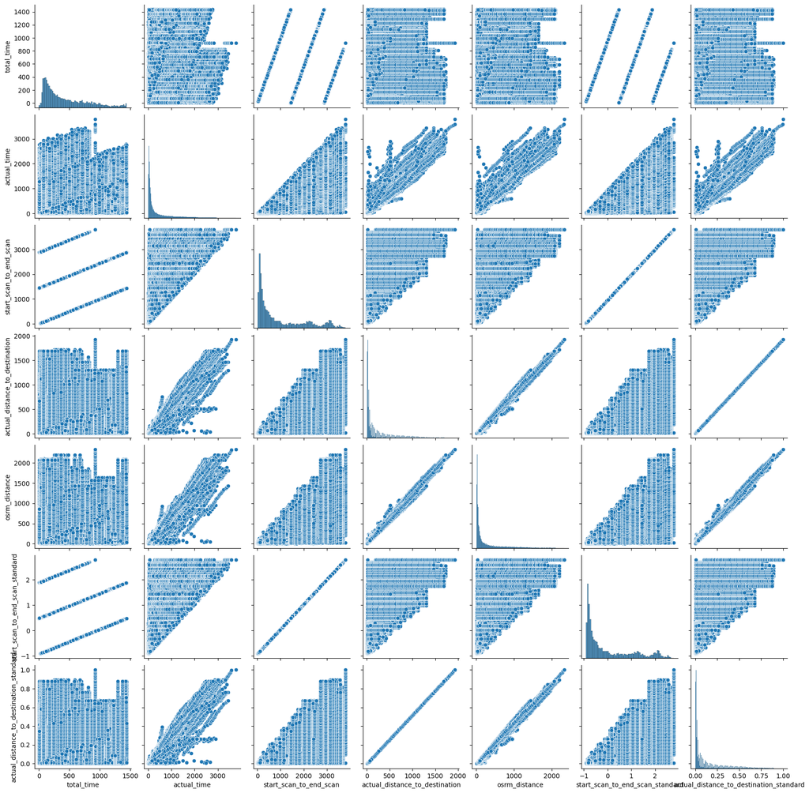

```python
plt.figure(figsize=(8,8))
sns.pairplot(data=df[['total_time','actual_time','start_scan_to_end_scan','actual_distance_to_destination','osrm_distance','start_scan_to_end_scan_standard','actual_distance_to_destination_standard']])
```

**Insight:** Comparison of different time and distance columns can be seen in the pairplot visualization above

# Checking relationship between aggregated fields

## Compare the difference between total_time and start_scan_to_end_scan Do hypothesis testing/ Visual analysis to check.

```python
#H0:The means of the distributions underlying the two samples are the same.
#H1:The means of the distributions underlying the two samples are NOT the same.
```

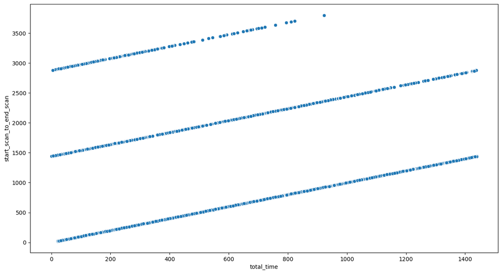

```python
plt.figure(figsize=(15,8))
sns.scatterplot(x='total_time',y='start_scan_to_end_scan',data=df)
plt.show()
```

```python
stat,pvalue = stats.ttest_ind(df['total_time'], df['start_scan_to_end_scan'])
pvalue
```

```
0.0
```

```python
alpha = 0.05
if pvalue < alpha:
    print("Reject H0")


else :
    print("cannot reject H0")
```

```
Reject H0
```

**Insight:** The means of the distributions underlying the two samples are NOT the same

## Do hypothesis testing/ visual analysis between actual_time aggregated value and OSRM time aggregated value

```python
#H0:The means of the distributions underlying the two samples are the same.
#H1:The means of the distributions underlying the two samples are NOT the same.
```

```python
stat,pvalue = stats.ttest_ind(actual_time_aggregated['actual_time'], OSRM_time_aggregated['osrm_time'])
pvalue
```

```
1.1384163488225839e-64
```

```python
alpha = 0.05
if pvalue < alpha:
    print("Reject H0")


else :
    print("cannot reject H0")
```

```
Reject H0
```

**Insight:** The means of the distributions underlying the two samples are NOT the same

## Do hypothesis testing/ visual analysis between actual_time aggregated value and segment actual time aggregated value

```python
#H0:The means of the distributions underlying the two samples are the same.
#H1:The means of the distributions underlying the two samples are NOT the same.
```

```python
stat,pvalue = stats.ttest_ind(actual_time_aggregated['actual_time'], segment_actual_time_aggregated['segment_actual_time'])
pvalue
```

```
1.6818148011237537e-298
```

```python
alpha = 0.05
if pvalue < alpha:
    print("Reject H0")


else :
    print("cannot reject H0")
```

```
Reject H0
```

**Insight:** The means of the distributions underlying the two samples are NOT the same

## Do hypothesis testing/ visual analysis between osrm distance aggregated value and segment osrm distance aggregated value

```python
#H0:The means of the distributions underlying the two samples are the same.
#H1:The means of the distributions underlying the two samples are NOT the same.
```

```python
stat,pvalue = stats.ttest_ind(osrm_distance_aggregated['osrm_distance'], segment_osrm_distance_aggregated['segment_osrm_distance'])
pvalue
```

```
1.4571870772969992e-277
```

```python
alpha = 0.05
if pvalue < alpha:
    print("Reject H0")


else :
    print("cannot reject H0")
```

```
Reject H0
```

**Insight:** The means of the distributions underlying the two samples are NOT the same

## Do hypothesis testing/ visual analysis between osrm time aggregated value and segment osrm time aggregated value

```python
#H0:The means of the distributions underlying the two samples are the same.
#H1:The means of the distributions underlying the two samples are NOT the same.
```

```python
stat,pvalue = stats.ttest_ind(OSRM_time_aggregated['osrm_time'], segment_osrm_time_aggregated['segment_osrm_time'])
pvalue
```

```
9.00889079257682e-286
```

```python
alpha = 0.05
if pvalue < alpha:
    print("Reject H0")


else :
    print("cannot reject H0")
```

```
Reject H0
```

**Insight:** The means of the distributions underlying the two samples are NOT the same

# Business Insights

## Check from where most orders are coming from (State, Corridor etc)

```python
temp=df["destination_code_state"].str.split(" ",  expand = True)
temp
```

|  | 0 | 1 | 2 | 3 | 4 |
| --- | --- | --- | --- | --- | --- |
| 0 | D | (Gujarat) | None | None | None |
| 1 | D | (Gujarat) | None | None | None |
| 2 | D | (Gujarat) | None | None | None |
| 3 | D | (Gujarat) | None | None | None |
| 4 | D | (Gujarat) | None | None | None |
| ... | ... | ... | ... | ... | ... |
| 144862 | HB | (Haryana) | None | None | None |
| 144863 | HB | (Haryana) | None | None | None |
| 144864 | HB | (Haryana) | None | None | None |
| 144865 | HB | (Haryana) | None | None | None |
| 144866 | HB | (Haryana) | None | None | None |

144494 rows × 5 columns

```python
df['destination_state_name']=temp[1]
```

```python
df.groupby(['destination_state_name']).aggregate({'route_schedule_uuid':'count'}).reset_index().sort_values('route_schedule_uuid')
```

|  | destination_state_name | route_schedule_uuid |
| --- | --- | --- |
| 18 | (Meghalaya) | 8 |
| 26 | (Tripura) | 9 |
| 19 | (Mizoram) | 31 |
| 6 | (Dadra | 34 |
| 8 | (Goa) | 74 |
| 21 | (Pondicherry) | 154 |
| 12 | (Jammu | 167 |
| 1 | (Arunachal | 185 |
| 5 | (Chhattisgarh) | 221 |
| 4 | (Chandigarh) | 282 |
| 20 | (Orissa) | 453 |
| 11 | (Himachal | 543 |
| 28 | (Uttarakhand) | 666 |
| 13 | (Jharkhand) | 1076 |
| 2 | (Assam) | 1250 |
| 15 | (Kerala) | 1835 |
| 9 | (Gujarat) | 2456 |
| 3 | (Bihar) | 2809 |
| 23 | (Rajasthan) | 3335 |
| 22 | (Punjab) | 3751 |
| 16 | (Madhya | 3853 |
| 27 | (Uttar | 4413 |
| 7 | (Delhi) | 5424 |
| 0 | (Andhra | 5983 |
| 29 | (West | 7051 |
| 24 | (Tamil | 7540 |
| 25 | (Telangana) | 8033 |
| 17 | (Maharashtra) | 15608 |
| 14 | (Karnataka) | 19676 |
| 10 | (Haryana) | 19747 |

```python
temp=df["source_code_state"].str.split(" ",  expand = True)
temp
```

|  | 0 | 1 | 2 | 3 | 4 |
| --- | --- | --- | --- | --- | --- |
| 0 | DC | (Gujarat) | None | None | None |
| 1 | DC | (Gujarat) | None | None | None |
| 2 | DC | (Gujarat) | None | None | None |
| 3 | DC | (Gujarat) | None | None | None |
| 4 | DC | (Gujarat) | None | None | None |
| ... | ... | ... | ... | ... | ... |
| 144862 | H | (Haryana) | None | None | None |
| 144863 | H | (Haryana) | None | None | None |
| 144864 | H | (Haryana) | None | None | None |
| 144865 | H | (Haryana) | None | None | None |
| 144866 | H | (Haryana) | None | None | None |

144494 rows × 5 columns

```python
df['source_state_name']=temp[1]
```

```python
df.groupby(['source_state_name']).aggregate({'route_schedule_uuid':'count'}).reset_index().sort_values('route_schedule_uuid')
```

|  | source_state_name | route_schedule_uuid |
| --- | --- | --- |
| 26 | (Tripura) | 5 |
| 19 | (Mizoram) | 26 |
| 6 | (Dadra | 30 |
| 21 | (Pondicherry) | 49 |
| 18 | (Meghalaya) | 77 |
| 1 | (Arunachal | 151 |
| 8 | (Goa) | 165 |
| 12 | (Jammu | 182 |
| 5 | (Chhattisgarh) | 229 |
| 4 | (Chandigarh) | 367 |
| 20 | (Orissa) | 404 |
| 11 | (Himachal | 532 |
| 28 | (Uttarakhand) | 827 |
| 2 | (Assam) | 1126 |
| 13 | (Jharkhand) | 1343 |
| 9 | (Gujarat) | 1867 |
| 15 | (Kerala) | 2038 |
| 3 | (Bihar) | 2206 |
| 22 | (Punjab) | 3381 |
| 23 | (Rajasthan) | 3530 |
| 16 | (Madhya | 3687 |
| 7 | (Delhi) | 4318 |
| 29 | (West | 4645 |
| 27 | (Uttar | 4791 |
| 0 | (Andhra | 5087 |
| 25 | (Telangana) | 6212 |
| 24 | (Tamil | 6697 |
| 14 | (Karnataka) | 18534 |
| 17 | (Maharashtra) | 18997 |
| 10 | (Haryana) | 26735 |

```python
df.groupby(['source_city']).aggregate({'route_schedule_uuid':'count'}).reset_index().sort_values('route_schedule_uuid')
```

|  | source_city | route_schedule_uuid |
| --- | --- | --- |
| 1200 | Tiruchi | 1 |
| 655 | Kothanalloor | 1 |
| 663 | Krishnanagar | 1 |
| 602 | Kayamkulam | 1 |
| 1155 | Sumerpur | 1 |
| ... | ... | ... |
| 140 | Bengaluru | 4237 |
| 970 | Pune | 4269 |
| 172 | Bhiwandi | 9088 |
| 102 | Bangalore | 10104 |
| 425 | Gurgaon | 23458 |

1272 rows × 2 columns

```python
df.groupby(['source_place']).aggregate({'route_schedule_uuid':'count'}).reset_index().sort_values('route_schedule_uuid')
```

|  | source_place | route_schedule_uuid |
| --- | --- | --- |
| 139 | BnkrGate | 1 |
| 849 | RajpurRD | 1 |
| 908 | Samyaprm | 1 |
| 32 | AnadiDPP | 1 |
| 914 | Sardhnrd | 1 |
| ... | ... | ... |
| 1031 | Tathawde | 4061 |
| 172 | Central | 8988 |
| 596 | Mankoli | 9088 |
| 719 | Nelmngla | 10053 |
| 127 | Bilaspur | 23257 |

1178 rows × 2 columns

```python
df.groupby(['destination_city']).aggregate({'route_schedule_uuid':'count'}).reset_index().sort_values('route_schedule_uuid')
```

|  | destination_city | route_schedule_uuid |
| --- | --- | --- |
| 623 | Khatauli | 1 |
| 281 | Daman | 1 |
| 433 | Hanskhali | 1 |
| 353 | Falna | 1 |
| 1052 | Salem | 1 |
| ... | ... | ... |
| 296 | Delhi | 5362 |
| 170 | Bhiwandi | 5511 |
| 462 | Hyderabad | 5838 |
| 105 | Bangalore | 11010 |
| 418 | Gurgaon | 15393 |

1271 rows × 2 columns

```python
df.groupby(['destination_place']).aggregate({'route_schedule_uuid':'count'}).reset_index().sort_values('route_schedule_uuid')
```

|  | destination_place | route_schedule_uuid |
| --- | --- | --- |
| 426 | Kadtmpty | 1 |
| 921 | ShivaDPP | 1 |
| 436 | Kalyan (Maharashtra) | 1 |
| 37 | ArickDPP | 1 |
| 900 | SbhRDDPP | 1 |
| ... | ... | ... |
| 912 | Shamshbd | 5309 |
| 581 | Mankoli | 5511 |
| 164 | Central | 9373 |
| 698 | Nelmngla | 10942 |
| 123 | Bilaspur | 15363 |

1154 rows × 2 columns

**Insight:** places like Gurgaon and Bilaspur in Haryana seems to be the place from where most orders are placed as seen above

## Busiest corridor, avg distance between them, avg time taken

```python
df.groupby(['source_city','destination_city']).aggregate({'route_schedule_uuid':'count','actual_distance_to_destination':'mean', 'total_time':'mean'}).reset_index().sort_values('route_schedule_uuid')
```

|  | source_city | destination_city | route_schedule_uuid | actual_distance_to_destination | total_time |
| --- | --- | --- | --- | --- | --- |
| 2377 | Vizag | Vishakhapatnam (Andhra Pradesh) | 1 | 9.228686 | 231.200000 |
| 1335 | Kottayam | Kothanalloor | 1 | 15.211748 | 399.620000 |
| 1432 | Mahasamund | Durg | 1 | 77.035515 | 902.830000 |
| 596 | Delhi | North Delhi (Delhi) | 1 | 9.045083 | 726.820000 |
| 1332 | Kothanalloor | Vaikom | 1 | 15.603861 | 57.380000 |
| ... | ... | ... | ... | ... | ... |
| 193 | Bangalore | Bengaluru | 1741 | 21.535381 | 220.859081 |
| 274 | Bengaluru | Bengaluru | 2062 | 22.267936 | 162.984753 |
| 844 | Gurgaon | Kolkata | 2802 | 672.777483 | 854.210525 |
| 201 | Bangalore | Gurgaon | 3316 | 869.072245 | 375.352325 |
| 819 | Gurgaon | Bangalore | 4899 | 859.844671 | 310.120988 |

2397 rows × 5 columns

**Insight:** Bangalore - Gurgaon - Bangalore seems to be the bussiest corridor of all

# Actionable items for business

- business should focus on routes other than just well developed routes like Gurgaon and bangalore
- They should use a different approach to calculate osrm time since the accuracy is not that high
- data capture for full source and destination name should be improved so that there are no missing values in data